# Module 175

#### Hemi-module gene counts:

459 probesets in hemi-module A.  
25 probesets in hemi-module B.  
Note: While the mapping of probesets to genes is usually one-to-one, some genes are targeted by multiple probesets, some probesets target multiple genes, and some probesets do not target any genes (i.e., the region of the genome they match is no longer considered genic).

#### Contrast SVE:

Signed variance explained (SVE) provides an indication of how similar a set of fold changes are to a gene module’s weight vector. An SVE value of 0.3, for example, indicates that 30% of the variance explained by the entire module set is accounted for by the module in question. Shown here are the SVE values for this module across a compendium of fold changes (contrasts). Extreme SVE values (e.g., > 0.05) indicate that those contrasts specifically induce (orange dots) or specifically repress (blue dots) this module. Examining the experimental conditions being compared in such contrasts (see tables below the figure) may provide insight into the gene module’s function.

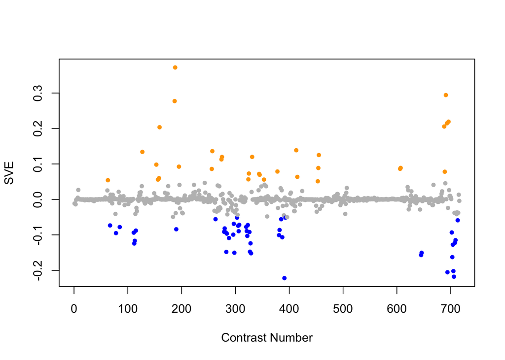

Positive SVE Contrasts:

|  | Contrast.Num | SVE | GEO.GSE | Cond.1 | Cond.2 | Mutation |
| --- | --- | --- | --- | --- | --- | --- |
| GSE46291.s2t1.vs.s1t1 | 188 | 0.37 | GSE46291 | L3-lethargus_rep1 | L3_rep1 |  |
| GSE11055.s4t7.vs.s2t7 | 691 | 0.29 | GSE11055 | L1 larvae fed for 12 hr after hatching and then starved for 3 hr | L1 larvae 15 hr after hatching in the absence of food |  |
| GSE46291.s2t2.vs.s1t2 | 187 | 0.28 | GSE46291 | L4-lethargus_rep1 | L4_rep1 |  |
| GSE11055.s1t7.vs.s5t7 | 696 | 0.22 | GSE11055 | L1-L2 larvae 15 hr after hatching in the presence of food | L1 larvae starved for 12 hr after hatching and then fed for 3 hr |  |
| GSE11055.s1t7.vs.s2t7 | 693 | 0.21 | GSE11055 | L1-L2 larvae 15 hr after hatching in the presence of food | L1 larvae 15 hr after hatching in the absence of food |  |
| GSE11055.s1t2.vs.s2t2 | 688 | 0.21 | GSE11055 | L1 larvae 0 hr after hatching in the presence of food | L1 larvae 0 hr after hatching in the absence of food |  |
| GSE47778.s5t1.vs.s1t1 | 159 | 0.20 | GSE47778 | xpa-1 0mJ/cm2; replicate 1 | N2; replicate 1 | xpa-1 |
| GSE29951.s1t2.vs.s0t2 | 413 | 0.14 | GSE29951 | C.elegans MT KO mtl-1,mtl-2(zs1) raised in the presence of Cd, rep1 | C.elegans wild type raised in the presence of Cd, rep1 | mtl-1;mtl-2 |
| GSE41366A.s1t2.vs.s0t2 | 257 | 0.14 | GSE41366 | low_DDVP-2h_expose-14h_harvest-rep1 | control-2h_expose-14h_harvest-rep1 |  |
| GSE54011.s2t1.vs.s0t1 | 127 | 0.13 | GSE54011 | Ce 0.1 mM Se | Ce 0 mM Se |  |
| GSE25513.s1t1.vs.s0t1 | 455 | 0.13 | GSE25513 | tax-6 null (1) | WT (1) | tax-6 |
| GSE38997.s4t4.vs.s3t4 | 331 | 0.12 | GSE38997 | experiment 1 UVC-exposed samples at 51 h 1u51 | experiment 1 UVC- and EtBr-exposed samples at 51 h 1eu51 |  |
| GSE41366B.s2t2.vs.s0t2 | 275 | 0.12 | GSE41366 | high_DDVP-8h_expose-20h_harvest-rep1 | control-8h_expose-20h_harvest-rep1 |  |
| GSE41366B.s1t1.vs.s0t1 | 274 | 0.11 | GSE41366 | low_DDVP-8h_expose-14h_harvest-rep1 | control-8h_expose-14h_harvest-rep1 |  |
| GSE47778.s5t1.vs.s3t1 | 153 | 0.10 | GSE47778 | xpa-1 0mJ/cm2; replicate 1 | daf-16; replicate 1 | xpa-1 vs. daf-16 |
| GSE43959.s2t1.vs.s3t1 | 195 | 0.09 | GSE43959 | N2 young adult on E. coli HT115 rep 1 | N2 young adult on Comamonas DA1877 rep 1 |  |
| GSE21784.s1t1.vs.s2t1 | 607 | 0.09 | GSE21784 | L4 larvae, biological rep1 | day 6 adults, biological rep 1 |  |
| GSE25513.s2t1.vs.s0t1 | 454 | 0.09 | GSE25513 | crh-1 null (1) | WT (1) | crh-1 |
| GSE21784.s1t1.vs.s3t1 | 606 | 0.09 | GSE21784 | L4 larvae, biological rep1 | day 15 adults, biological rep 1 |  |
| GSE41366A.s2t2.vs.s0t2 | 256 | 0.09 | GSE41366 | high_DDVP-2h_expose-14h_harvest-rep1 | control-2h_expose-14h_harvest-rep1 |  |
| GSE35354B.s1t4.vs.s1t1 | 378 | 0.08 | GSE35354 | TA300_rep1 | TA Control_rep1 |  |
| GSE11055.s1t3.vs.s2t3 | 689 | 0.08 | GSE11055 | L1 larvae 1 hr after hatching in the presence of food | L1 larvae 1 hr after hatching in the absence of food |  |
| GSE38997.s4t3.vs.s3t3 | 325 | 0.07 | GSE38997 | experiment 1 UVC-exposed samples at 48 h 1u48 | experiment 1 UVC- and EtBr-exposed samples at 48 h 1eu48 |  |
| GSE38997.s1t3.vs.s1t1 | 344 | 0.07 | GSE38997 | experiment 1 control samples at 48 h 1c48 | experiment 4 control samples at 3 h 4c3 |  |
| GSE38997.s1t4.vs.s1t1 | 345 | 0.07 | GSE38997 | experiment 1 control samples at 51 h 1c51 | experiment 4 control samples at 3 h 4c3 |  |
| GSE29951.s1t2.vs.s1t1 | 415 | 0.06 | GSE29951 | C.elegans MT KO mtl-1,mtl-2(zs1) raised in the presence of Cd, rep1 | C.elegans MT KO mtl-1,mtl-2(zs1), raised in the absence of Cd, rep1 | mtl-1;mtl-2 |
| GSE47778.s5t1.vs.s4t1 | 158 | 0.06 | GSE47778 | xpa-1 0mJ/cm2; replicate 1 | daf-2;daf-16; replicate 1 | xpa-1 vs. daf-2;daf-16 |
| GSE38997.s4t3.vs.s2t3 | 324 | 0.06 | GSE38997 | experiment 1 UVC-exposed samples at 48 h 1u48 | experiment 1 EtBr-exposed samples at 48 h 1e48 |  |
| GSE38997.s4t3.vs.s4t1 | 353 | 0.06 | GSE38997 | experiment 1 UVC-exposed samples at 48 h 1u48 | experiment 4 UVC-exposed samples at 3 h 4u3 |  |
| GSE47778.s5t1.vs.s2t1 | 156 | 0.06 | GSE47778 | xpa-1 0mJ/cm2; replicate 1 | daf-2; replicate 1 | xpa-1 vs. daf-2 |
| GSE8696.s3t1.vs.s2t1 | 63 | 0.05 | GSE8696 | 500 uM hemin (500A) | 20 uM hemin (20A) |  |
| GSE25513.s3t1.vs.s0t1 | 453 | 0.05 | GSE25513 | aak-2 o/e (1) | WT (1) | aak-2 |

Negative SVE Contrasts:

|  | Contrast.Num | SVE | GEO.GSE | Cond.1 | Cond.2 | Mutation |
| --- | --- | --- | --- | --- | --- | --- |
| GSE32467.s1t1.vs.s0t1 | 391 | -0.22 | GSE32467 | unc-37(e262) A-class, biological rep1 | wildtype A-class, biological rep1 | unc-37 |
| GSE11055.s1t5.vs.s1t1 | 706 | -0.22 | GSE11055 | L1 larvae 6 hr after hatching in the presence of food | embryo 2 hr before hatching |  |
| GSE11055.s5t7.vs.s4t7 | 694 | -0.21 | GSE11055 | L1 larvae starved for 12 hr after hatching and then fed for 3 hr | L1 larvae fed for 12 hr after hatching and then starved for 3 hr |  |
| GSE11055.s1t4.vs.s1t1 | 705 | -0.20 | GSE11055 | L1 larvae 3 hr after hatching in the presence of food | embryo 2 hr before hatching |  |
| GSE11055.s1t3.vs.s1t1 | 703 | -0.16 | GSE11055 | L1 larvae 1 hr after hatching in the presence of food | embryo 2 hr before hatching |  |
| GSE16915.s2t1.vs.s3t1 | 645 | -0.16 | GSE16915 | positive control (heat shock) | bio-electrosprayed sample |  |
| GSE38997.s3t4.vs.s2t4 | 329 | -0.15 | GSE38997 | experiment 1 UVC- and EtBr-exposed samples at 51 h 1eu51 | experiment 1 EtBr-exposed samples at 51 h 1e51 |  |
| GSE16915.s2t1.vs.s1t1 | 646 | -0.15 | GSE16915 | positive control (heat shock) | control sample |  |
| GSE41366C.s0t2.vs.s0t1 | 298 | -0.15 | GSE41366 | control-continuous_expose-2h_harvest-rep1 | control-continuous_expose-0h_harvest-rep2 |  |
| GSE41366B.s1t2.vs.s1t1 | 283 | -0.15 | GSE41366 | low_DDVP-8h_expose-20h_harvest-rep1 | low_DDVP-8h_expose-14h_harvest-rep1 |  |
| GSE38997.s3t4.vs.s1t4 | 327 | -0.15 | GSE38997 | experiment 1 UVC- and EtBr-exposed samples at 51 h 1eu51 | experiment 1 control samples at 51 h 1c51 |  |
| GSE11055.s1t6.vs.s1t1 | 704 | -0.13 | GSE11055 | L1 larvae 12 hr after hatching in the presence of food | embryo 2 hr before hatching |  |
| GSE54024.s4t1.vs.s5t1 | 112 | -0.12 | GSE54024 | isp-1(qm150) young adults, biological rep 1 | ced-4(n1162) young adults, biological rep 1 |  |
| GSE38997.s4t4.vs.s1t4 | 328 | -0.12 | GSE38997 | experiment 1 UVC-exposed samples at 51 h 1u51 | experiment 1 control samples at 51 h 1c51 |  |
| GSE11055.s1t8.vs.s1t1 | 708 | -0.12 | GSE11055 | L2 larvae 24 hr after hatching in the presence of food | embryo 2 hr before hatching |  |
| GSE54024.s3t1.vs.s5t1 | 113 | -0.12 | GSE54024 | nuo-6(qm200) young adults, biological rep 1 | ced-4(n1162) young adults, biological rep 1 |  |
| GSE11055.s2t3.vs.s2t2 | 709 | -0.11 | GSE11055 | L1 larvae 1 hr after hatching in the absence of food | L1 larvae 0 hr after hatching in the absence of food |  |
| GSE41366C.s1t4.vs.s0t4 | 288 | -0.11 | GSE41366 | low_DDVP-continuous_expose-20h_harvest-rep1 | control-continuous_expose-14h_harvest-rep1 |  |
| GSE34026.s1t1.vs.s0t1 | 387 | -0.11 | GSE34026 | N2 exposed to hemolysin mutant of E7946, biological rep1 | N2 exposed to OP50(E.coli), biological rep1 |  |
| GSE38997.s4t3.vs.s1t3 | 322 | -0.10 | GSE38997 | experiment 1 UVC-exposed samples at 48 h 1u48 | experiment 1 control samples at 48 h 1c48 |  |
| GSE34471.s0t2.vs.s0t1 | 381 | -0.10 | GSE34471 | 20uM-Con-1 | 4uM-Con-1 |  |
| GSE41366C.s0t5.vs.s0t1 | 296 | -0.10 | GSE41366 | control-continuous_expose-20h_harvest-rep1 | control-continuous_expose-0h_harvest-rep2 |  |
| GSE41366B.s1t3.vs.s1t1 | 284 | -0.10 | GSE41366 | low_DDVP-8h_expose-26h_harvest-rep1 | low_DDVP-8h_expose-14h_harvest-rep1 |  |
| GSE8004.s2t2.vs.s1t2 | 78 | -0.10 | GSE8004 | Larval Reference, biological rep 1 of set 1 | Larval A-class, biological rep 1 of set 3 |  |
| GSE54024.s6t1.vs.s5t1 | 111 | -0.09 | GSE54024 | isp-1(qm150) ced-4(n1162) double mutant young adults, biological rep 1 | ced-4(n1162) young adults, biological rep 1 | isp-1 |
| GSE11055.s1t2.vs.s1t1 | 702 | -0.09 | GSE11055 | L1 larvae 0 hr after hatching in the presence of food | embryo 2 hr before hatching |  |
| GSE41366B.s2t3.vs.s2t1 | 282 | -0.09 | GSE41366 | high_DDVP-8h_expose-26h_harvest-rep1 | high_DDVP-8h_expose-14h_harvest-rep1 |  |
| GSE38997.s2t4.vs.s1t4 | 326 | -0.09 | GSE38997 | experiment 1 EtBr-exposed samples at 51 h 1e51 | experiment 1 control samples at 51 h 1c51 |  |
| GSE41366B.s0t2.vs.s0t1 | 279 | -0.09 | GSE41366 | control-8h_expose-20h_harvest-rep1 | control-8h_expose-14h_harvest-rep1 |  |
| GSE41366C.s1t5.vs.s1t1 | 306 | -0.09 | GSE41366 | low_DDVP-continuous_expose-26h_harvest-rep1 | low_DDVP-continuous_expose-2h_harvest-rep1 |  |
| GSE38997.s3t3.vs.s1t3 | 321 | -0.09 | GSE38997 | experiment 1 UVC- and EtBr-exposed samples at 48 h 1eu48 | experiment 1 control samples at 48 h 1c48 |  |
| GSE54024.s1t1.vs.s5t1 | 115 | -0.09 | GSE54024 | Wild type young adults, biological rep 1 | ced-4(n1162) young adults, biological rep 1 | ced-4 |
| GSE34471.s1t2.vs.s1t1 | 382 | -0.09 | GSE34471 | 20uM-Exp1 | 4uM-Exp1 |  |
| GSE46291.s1t2.vs.s1t1 | 190 | -0.08 | GSE46291 | L4_rep1 | L3_rep1 |  |
| GSE41366B.s0t3.vs.s0t1 | 280 | -0.08 | GSE41366 | control-8h_expose-26h_harvest-rep1 | control-8h_expose-14h_harvest-rep1 |  |
| GSE6547.s1t2.vs.s0t2 | 85 | -0.08 | GSE6547 | lin-35(n745) worms at L1 stage, first replicate | N2 (wt) worms at L1 stage, first replicate | lin-35 |
| GSE38997.s2t3.vs.s1t3 | 320 | -0.08 | GSE38997 | experiment 1 EtBr-exposed samples at 48 h 1e48 | experiment 1 control samples at 48 h 1c48 |  |
| GSE41366C.s1t4.vs.s1t1 | 305 | -0.07 | GSE41366 | low_DDVP-continuous_expose-20h_harvest-rep1 | low_DDVP-continuous_expose-2h_harvest-rep1 |  |
| GSE8659.s3t1.vs.s2t1 | 67 | -0.07 | GSE8659 | strain NL 2099 replicate 2 | strain GR1373 replicate 1 |  |
| GSE38997.s3t3.vs.s2t3 | 323 | -0.07 | GSE38997 | experiment 1 UVC- and EtBr-exposed samples at 48 h 1eu48 | experiment 1 EtBr-exposed samples at 48 h 1e48 |  |
| GSE41366C.s1t2.vs.s1t1 | 307 | -0.07 | GSE41366 | low_DDVP-continuous_expose-8h_harvest-rep1 | low_DDVP-continuous_expose-2h_harvest-rep1 |  |
| GSE41366C.s0t6.vs.s0t1 | 297 | -0.07 | GSE41366 | control-continuous_expose-26h_harvest-rep1 | control-continuous_expose-0h_harvest-rep2 |  |
| GSE11055.s2t4.vs.s2t2 | 713 | -0.06 | GSE11055 | L1 larvae 3 hr after hatching in the absence of food | L1 larvae 0 hr after hatching in the absence of food |  |
| GSE34026.s3t1.vs.s0t1 | 385 | -0.06 | GSE34026 | N2 exposed to CVD110, biological rep1 | N2 exposed to OP50(E.coli), biological rep1 |  |
| GSE41366A.s1t1.vs.s0t1 | 263 | -0.06 | GSE41366 | low_DDVP-2h_expose-8h_harvest-rep1 | control-2h_expose-8h_harvest-rep1 |  |
| GSE41366C.s2t2.vs.s2t1 | 303 | -0.05 | GSE41366 | high_DDVP-continuous_expose-8h_harvest-rep1 | high_DDVP-continuous_expose-2h_harvest-rep1 |  |
| GSE32339.s1t1.vs.s0t1 | 393 | -0.05 | GSE32339 | Larval Mutant, biological rep1 | Larval Wild-type, biological rep1 | nep-1 |

$~$

#### Contrast SVE, Up-Regulated Genes Only:

Calculating SVE for up-regulated and down-regulated genes separately may be more informative in many cases than projecting the up- and down- gene sets together. This is due to the fact that the weight distribution of many modules is highly skewed, indicating that only one of the hemi-modules may be biologically meaningful (i.e., a set of genes are strongly correlated by only a few genes (or none) are strongly anti-correlated to that set.)

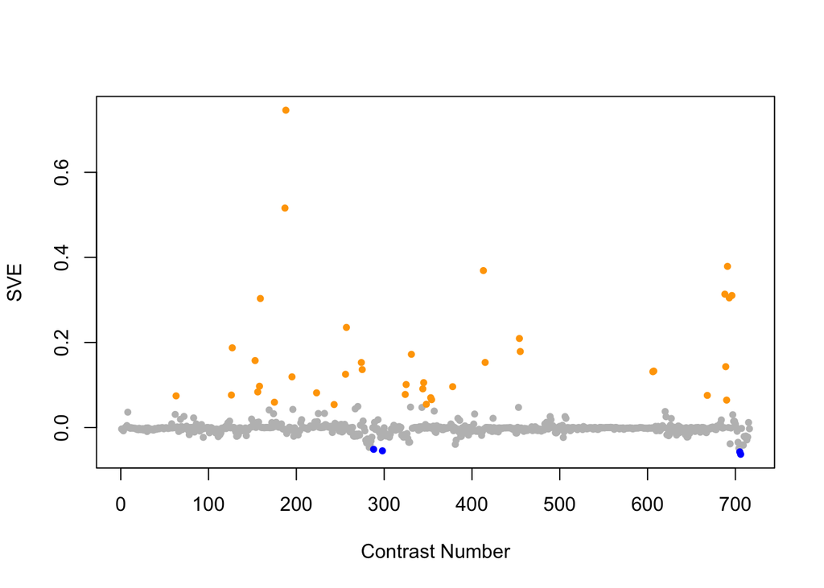

Positive SVE Contrasts:

|  | Contrast.Num | SVE | GEO.GSE | Cond.1 | Cond.2 | Mutation |
| --- | --- | --- | --- | --- | --- | --- |
| GSE46291.s2t1.vs.s1t1 | 188 | 0.75 | GSE46291 | L3-lethargus_rep1 | L3_rep1 |  |
| GSE46291.s2t2.vs.s1t2 | 187 | 0.52 | GSE46291 | L4-lethargus_rep1 | L4_rep1 |  |
| GSE11055.s4t7.vs.s2t7 | 691 | 0.38 | GSE11055 | L1 larvae fed for 12 hr after hatching and then starved for 3 hr | L1 larvae 15 hr after hatching in the absence of food |  |
| GSE29951.s1t2.vs.s0t2 | 413 | 0.37 | GSE29951 | C.elegans MT KO mtl-1,mtl-2(zs1) raised in the presence of Cd, rep1 | C.elegans wild type raised in the presence of Cd, rep1 | mtl-1;mtl-2 |
| GSE11055.s1t2.vs.s2t2 | 688 | 0.31 | GSE11055 | L1 larvae 0 hr after hatching in the presence of food | L1 larvae 0 hr after hatching in the absence of food |  |
| GSE11055.s1t7.vs.s5t7 | 696 | 0.31 | GSE11055 | L1-L2 larvae 15 hr after hatching in the presence of food | L1 larvae starved for 12 hr after hatching and then fed for 3 hr |  |
| GSE11055.s1t7.vs.s2t7 | 693 | 0.30 | GSE11055 | L1-L2 larvae 15 hr after hatching in the presence of food | L1 larvae 15 hr after hatching in the absence of food |  |
| GSE47778.s5t1.vs.s1t1 | 159 | 0.30 | GSE47778 | xpa-1 0mJ/cm2; replicate 1 | N2; replicate 1 | xpa-1 |
| GSE41366A.s1t2.vs.s0t2 | 257 | 0.24 | GSE41366 | low_DDVP-2h_expose-14h_harvest-rep1 | control-2h_expose-14h_harvest-rep1 |  |
| GSE25513.s2t1.vs.s0t1 | 454 | 0.21 | GSE25513 | crh-1 null (1) | WT (1) | crh-1 |
| GSE54011.s2t1.vs.s0t1 | 127 | 0.19 | GSE54011 | Ce 0.1 mM Se | Ce 0 mM Se |  |
| GSE25513.s1t1.vs.s0t1 | 455 | 0.18 | GSE25513 | tax-6 null (1) | WT (1) | tax-6 |
| GSE38997.s4t4.vs.s3t4 | 331 | 0.17 | GSE38997 | experiment 1 UVC-exposed samples at 51 h 1u51 | experiment 1 UVC- and EtBr-exposed samples at 51 h 1eu51 |  |
| GSE47778.s5t1.vs.s3t1 | 153 | 0.16 | GSE47778 | xpa-1 0mJ/cm2; replicate 1 | daf-16; replicate 1 | xpa-1 vs. daf-16 |
| GSE29951.s1t2.vs.s1t1 | 415 | 0.15 | GSE29951 | C.elegans MT KO mtl-1,mtl-2(zs1) raised in the presence of Cd, rep1 | C.elegans MT KO mtl-1,mtl-2(zs1), raised in the absence of Cd, rep1 | mtl-1;mtl-2 |
| GSE41366B.s1t1.vs.s0t1 | 274 | 0.15 | GSE41366 | low_DDVP-8h_expose-14h_harvest-rep1 | control-8h_expose-14h_harvest-rep1 |  |
| GSE11055.s1t3.vs.s2t3 | 689 | 0.14 | GSE11055 | L1 larvae 1 hr after hatching in the presence of food | L1 larvae 1 hr after hatching in the absence of food |  |
| GSE41366B.s2t2.vs.s0t2 | 275 | 0.14 | GSE41366 | high_DDVP-8h_expose-20h_harvest-rep1 | control-8h_expose-20h_harvest-rep1 |  |
| GSE21784.s1t1.vs.s2t1 | 607 | 0.13 | GSE21784 | L4 larvae, biological rep1 | day 6 adults, biological rep 1 |  |
| GSE21784.s1t1.vs.s3t1 | 606 | 0.13 | GSE21784 | L4 larvae, biological rep1 | day 15 adults, biological rep 1 |  |
| GSE41366A.s2t2.vs.s0t2 | 256 | 0.13 | GSE41366 | high_DDVP-2h_expose-14h_harvest-rep1 | control-2h_expose-14h_harvest-rep1 |  |
| GSE43959.s2t1.vs.s3t1 | 195 | 0.12 | GSE43959 | N2 young adult on E. coli HT115 rep 1 | N2 young adult on Comamonas DA1877 rep 1 |  |
| GSE38997.s1t4.vs.s1t1 | 345 | 0.11 | GSE38997 | experiment 1 control samples at 51 h 1c51 | experiment 4 control samples at 3 h 4c3 |  |
| GSE38997.s4t3.vs.s3t3 | 325 | 0.10 | GSE38997 | experiment 1 UVC-exposed samples at 48 h 1u48 | experiment 1 UVC- and EtBr-exposed samples at 48 h 1eu48 |  |
| GSE47778.s5t1.vs.s4t1 | 158 | 0.10 | GSE47778 | xpa-1 0mJ/cm2; replicate 1 | daf-2;daf-16; replicate 1 | xpa-1 vs. daf-2;daf-16 |
| GSE35354B.s1t4.vs.s1t1 | 378 | 0.10 | GSE35354 | TA300_rep1 | TA Control_rep1 |  |
| GSE38997.s1t3.vs.s1t1 | 344 | 0.09 | GSE38997 | experiment 1 control samples at 48 h 1c48 | experiment 4 control samples at 3 h 4c3 |  |
| GSE47778.s5t1.vs.s2t1 | 156 | 0.08 | GSE47778 | xpa-1 0mJ/cm2; replicate 1 | daf-2; replicate 1 | xpa-1 vs. daf-2 |
| GSE42592A.s3t3.vs.s3t2 | 223 | 0.08 | GSE42592 | acrylamide_high_expose-8h_rep1 | acrylamide_high_expose-4h_rep1 |  |
| GSE38997.s4t3.vs.s2t3 | 324 | 0.08 | GSE38997 | experiment 1 UVC-exposed samples at 48 h 1u48 | experiment 1 EtBr-exposed samples at 48 h 1e48 |  |
| GSE54011.s1t1.vs.s0t1 | 126 | 0.08 | GSE54011 | Ce 0.05 mM Se | Ce 0 mM Se |  |
| GSE15016.s4t1.vs.s0t1 | 668 | 0.08 | GSE15016 | young adult_24hr BPA exposure_rep1 | young adult_not exposured_rep1 |  |
| GSE8696.s3t1.vs.s2t1 | 63 | 0.07 | GSE8696 | 500 uM hemin (500A) | 20 uM hemin (20A) |  |
| GSE38997.s4t3.vs.s4t1 | 353 | 0.07 | GSE38997 | experiment 1 UVC-exposed samples at 48 h 1u48 | experiment 4 UVC-exposed samples at 3 h 4u3 |  |
| GSE38997.s4t4.vs.s4t1 | 354 | 0.07 | GSE38997 | experiment 1 UVC-exposed samples at 51 h 1u51 | experiment 4 UVC-exposed samples at 3 h 4u3 |  |
| GSE11055.s1t6.vs.s2t6 | 690 | 0.06 | GSE11055 | L1 larvae 12 hr after hatching in the presence of food | L1 larvae 12 hr after hatching in the absence of food |  |
| GSE47778.s5t3.vs.s1t3 | 175 | 0.06 | GSE47778 | xpa-1 10mJ/cm2; replicate 1 | N2; UV; replicate 1 | xpa-1 |
| GSE38997.s2t4.vs.s2t1 | 348 | 0.05 | GSE38997 | experiment 1 EtBr-exposed samples at 51 h 1e51 | experiment 4 EtBr-exposed samples at 3 h 4e3 |  |
| GSE42592C.s0t2.vs.s0t1 | 243 | 0.05 | GSE42592 | mercury_control_expose-4h_rep1 | mercury_control_expose-0h_rep1 |  |

Negative SVE Contrasts:

|  | Contrast.Num | SVE | GEO.GSE | Cond.1 | Cond.2 | Mutation |
| --- | --- | --- | --- | --- | --- | --- |
| GSE11055.s1t5.vs.s1t1 | 706 | -0.06 | GSE11055 | L1 larvae 6 hr after hatching in the presence of food | embryo 2 hr before hatching |  |
| GSE11055.s1t4.vs.s1t1 | 705 | -0.06 | GSE11055 | L1 larvae 3 hr after hatching in the presence of food | embryo 2 hr before hatching |  |
| GSE41366C.s0t2.vs.s0t1 | 298 | -0.05 | GSE41366 | control-continuous_expose-2h_harvest-rep1 | control-continuous_expose-0h_harvest-rep2 |  |
| GSE41366C.s1t4.vs.s0t4 | 288 | -0.05 | GSE41366 | low_DDVP-continuous_expose-20h_harvest-rep1 | control-continuous_expose-14h_harvest-rep1 |  |
| GSE11055.s1t6.vs.s1t1 | 704 | -0.05 | GSE11055 | L1 larvae 12 hr after hatching in the presence of food | embryo 2 hr before hatching |  |

$~$

#### Contrast SVE, Down-Regulated Genes Only:

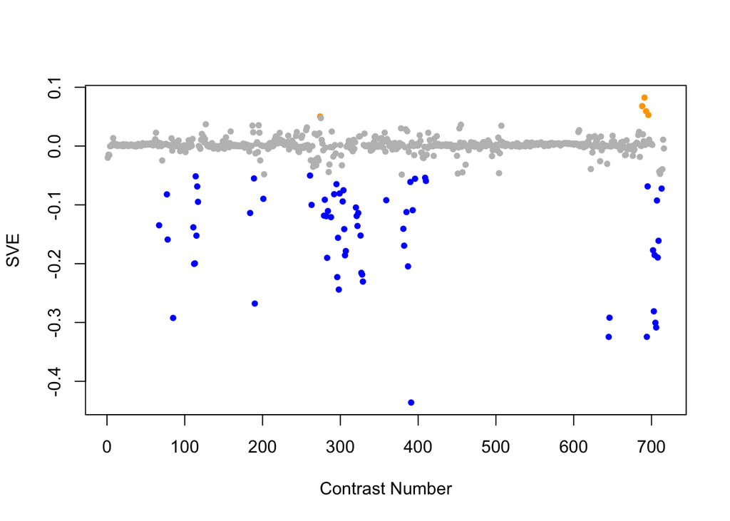

Positive SVE Contrasts:

|  | Contrast.Num | SVE | GEO.GSE | Cond.1 | Cond.2 | Mutation |
| --- | --- | --- | --- | --- | --- | --- |
| GSE11055.s4t7.vs.s2t7 | 691 | 0.08 | GSE11055 | L1 larvae fed for 12 hr after hatching and then starved for 3 hr | L1 larvae 15 hr after hatching in the absence of food |  |
| GSE11055.s1t2.vs.s2t2 | 688 | 0.07 | GSE11055 | L1 larvae 0 hr after hatching in the presence of food | L1 larvae 0 hr after hatching in the absence of food |  |
| GSE11055.s1t7.vs.s2t7 | 693 | 0.06 | GSE11055 | L1-L2 larvae 15 hr after hatching in the presence of food | L1 larvae 15 hr after hatching in the absence of food |  |
| GSE11055.s1t7.vs.s5t7 | 696 | 0.05 | GSE11055 | L1-L2 larvae 15 hr after hatching in the presence of food | L1 larvae starved for 12 hr after hatching and then fed for 3 hr |  |
| GSE41366B.s1t1.vs.s0t1 | 274 | 0.05 | GSE41366 | low_DDVP-8h_expose-14h_harvest-rep1 | control-8h_expose-14h_harvest-rep1 |  |

Negative SVE Contrasts:

|  | Contrast.Num | SVE | GEO.GSE | Cond.1 | Cond.2 | Mutation |
| --- | --- | --- | --- | --- | --- | --- |
| GSE32467.s1t1.vs.s0t1 | 391 | -0.44 | GSE32467 | unc-37(e262) A-class, biological rep1 | wildtype A-class, biological rep1 | unc-37 |
| GSE16915.s2t1.vs.s3t1 | 645 | -0.32 | GSE16915 | positive control (heat shock) | bio-electrosprayed sample |  |
| GSE11055.s5t7.vs.s4t7 | 694 | -0.32 | GSE11055 | L1 larvae starved for 12 hr after hatching and then fed for 3 hr | L1 larvae fed for 12 hr after hatching and then starved for 3 hr |  |
| GSE11055.s1t5.vs.s1t1 | 706 | -0.31 | GSE11055 | L1 larvae 6 hr after hatching in the presence of food | embryo 2 hr before hatching |  |
| GSE11055.s1t4.vs.s1t1 | 705 | -0.30 | GSE11055 | L1 larvae 3 hr after hatching in the presence of food | embryo 2 hr before hatching |  |
| GSE6547.s1t2.vs.s0t2 | 85 | -0.29 | GSE6547 | lin-35(n745) worms at L1 stage, first replicate | N2 (wt) worms at L1 stage, first replicate | lin-35 |
| GSE16915.s2t1.vs.s1t1 | 646 | -0.29 | GSE16915 | positive control (heat shock) | control sample |  |
| GSE11055.s1t3.vs.s1t1 | 703 | -0.28 | GSE11055 | L1 larvae 1 hr after hatching in the presence of food | embryo 2 hr before hatching |  |
| GSE46291.s1t2.vs.s1t1 | 190 | -0.27 | GSE46291 | L4_rep1 | L3_rep1 |  |
| GSE41366C.s0t2.vs.s0t1 | 298 | -0.24 | GSE41366 | control-continuous_expose-2h_harvest-rep1 | control-continuous_expose-0h_harvest-rep2 |  |
| GSE38997.s3t4.vs.s2t4 | 329 | -0.23 | GSE38997 | experiment 1 UVC- and EtBr-exposed samples at 51 h 1eu51 | experiment 1 EtBr-exposed samples at 51 h 1e51 |  |
| GSE41366C.s0t5.vs.s0t1 | 296 | -0.22 | GSE41366 | control-continuous_expose-20h_harvest-rep1 | control-continuous_expose-0h_harvest-rep2 |  |
| GSE38997.s4t4.vs.s1t4 | 328 | -0.22 | GSE38997 | experiment 1 UVC-exposed samples at 51 h 1u51 | experiment 1 control samples at 51 h 1c51 |  |
| GSE38997.s3t4.vs.s1t4 | 327 | -0.22 | GSE38997 | experiment 1 UVC- and EtBr-exposed samples at 51 h 1eu51 | experiment 1 control samples at 51 h 1c51 |  |
| GSE34026.s1t1.vs.s0t1 | 387 | -0.20 | GSE34026 | N2 exposed to hemolysin mutant of E7946, biological rep1 | N2 exposed to OP50(E.coli), biological rep1 |  |
| GSE54024.s4t1.vs.s5t1 | 112 | -0.20 | GSE54024 | isp-1(qm150) young adults, biological rep 1 | ced-4(n1162) young adults, biological rep 1 |  |
| GSE54024.s3t1.vs.s5t1 | 113 | -0.20 | GSE54024 | nuo-6(qm200) young adults, biological rep 1 | ced-4(n1162) young adults, biological rep 1 |  |
| GSE41366B.s1t2.vs.s1t1 | 283 | -0.19 | GSE41366 | low_DDVP-8h_expose-20h_harvest-rep1 | low_DDVP-8h_expose-14h_harvest-rep1 |  |
| GSE11055.s1t8.vs.s1t1 | 708 | -0.19 | GSE11055 | L2 larvae 24 hr after hatching in the presence of food | embryo 2 hr before hatching |  |
| GSE41366C.s1t5.vs.s1t1 | 306 | -0.19 | GSE41366 | low_DDVP-continuous_expose-26h_harvest-rep1 | low_DDVP-continuous_expose-2h_harvest-rep1 |  |
| GSE11055.s1t6.vs.s1t1 | 704 | -0.19 | GSE11055 | L1 larvae 12 hr after hatching in the presence of food | embryo 2 hr before hatching |  |
| GSE41366C.s1t2.vs.s1t1 | 307 | -0.18 | GSE41366 | low_DDVP-continuous_expose-8h_harvest-rep1 | low_DDVP-continuous_expose-2h_harvest-rep1 |  |
| GSE11055.s1t2.vs.s1t1 | 702 | -0.18 | GSE11055 | L1 larvae 0 hr after hatching in the presence of food | embryo 2 hr before hatching |  |
| GSE34471.s1t2.vs.s1t1 | 382 | -0.17 | GSE34471 | 20uM-Exp1 | 4uM-Exp1 |  |
| GSE11055.s2t3.vs.s2t2 | 709 | -0.16 | GSE11055 | L1 larvae 1 hr after hatching in the absence of food | L1 larvae 0 hr after hatching in the absence of food |  |
| GSE8004.s2t2.vs.s1t2 | 78 | -0.16 | GSE8004 | Larval Reference, biological rep 1 of set 1 | Larval A-class, biological rep 1 of set 3 |  |
| GSE41366C.s0t6.vs.s0t1 | 297 | -0.16 | GSE41366 | control-continuous_expose-26h_harvest-rep1 | control-continuous_expose-0h_harvest-rep2 |  |
| GSE54024.s1t1.vs.s5t1 | 115 | -0.15 | GSE54024 | Wild type young adults, biological rep 1 | ced-4(n1162) young adults, biological rep 1 | ced-4 |
| GSE38997.s2t4.vs.s1t4 | 326 | -0.15 | GSE38997 | experiment 1 EtBr-exposed samples at 51 h 1e51 | experiment 1 control samples at 51 h 1c51 |  |
| GSE41366C.s1t4.vs.s1t1 | 305 | -0.14 | GSE41366 | low_DDVP-continuous_expose-20h_harvest-rep1 | low_DDVP-continuous_expose-2h_harvest-rep1 |  |
| GSE34471.s0t2.vs.s0t1 | 381 | -0.14 | GSE34471 | 20uM-Con-1 | 4uM-Con-1 |  |
| GSE54024.s6t1.vs.s5t1 | 111 | -0.14 | GSE54024 | isp-1(qm150) ced-4(n1162) double mutant young adults, biological rep 1 | ced-4(n1162) young adults, biological rep 1 | isp-1 |
| GSE38997.s4t3.vs.s1t3 | 322 | -0.14 | GSE38997 | experiment 1 UVC-exposed samples at 48 h 1u48 | experiment 1 control samples at 48 h 1c48 |  |
| GSE8659.s3t1.vs.s2t1 | 67 | -0.13 | GSE8659 | strain NL 2099 replicate 2 | strain GR1373 replicate 1 |  |
| GSE41366C.s1t4.vs.s0t4 | 288 | -0.12 | GSE41366 | low_DDVP-continuous_expose-20h_harvest-rep1 | control-continuous_expose-14h_harvest-rep1 |  |
| GSE41366B.s2t3.vs.s2t1 | 282 | -0.12 | GSE41366 | high_DDVP-8h_expose-26h_harvest-rep1 | high_DDVP-8h_expose-14h_harvest-rep1 |  |
| GSE38997.s3t3.vs.s1t3 | 321 | -0.12 | GSE38997 | experiment 1 UVC- and EtBr-exposed samples at 48 h 1eu48 | experiment 1 control samples at 48 h 1c48 |  |
| GSE41366B.s0t2.vs.s0t1 | 279 | -0.12 | GSE41366 | control-8h_expose-20h_harvest-rep1 | control-8h_expose-14h_harvest-rep1 |  |
| GSE47778.s5t3.vs.s5t1 | 184 | -0.11 | GSE47778 | xpa-1 10mJ/cm2; replicate 1 | xpa-1 0mJ/cm2; replicate 1 |  |
| GSE38997.s3t3.vs.s2t3 | 323 | -0.11 | GSE38997 | experiment 1 UVC- and EtBr-exposed samples at 48 h 1eu48 | experiment 1 EtBr-exposed samples at 48 h 1e48 |  |
| GSE34026.s3t1.vs.s0t1 | 385 | -0.11 | GSE34026 | N2 exposed to CVD110, biological rep1 | N2 exposed to OP50(E.coli), biological rep1 |  |
| GSE41366B.s1t3.vs.s1t1 | 284 | -0.11 | GSE41366 | low_DDVP-8h_expose-26h_harvest-rep1 | low_DDVP-8h_expose-14h_harvest-rep1 |  |
| GSE32339.s1t1.vs.s0t1 | 393 | -0.11 | GSE32339 | Larval Mutant, biological rep1 | Larval Wild-type, biological rep1 | nep-1 |
| GSE38997.s2t3.vs.s1t3 | 320 | -0.10 | GSE38997 | experiment 1 EtBr-exposed samples at 48 h 1e48 | experiment 1 control samples at 48 h 1c48 |  |
| GSE41366A.s1t1.vs.s0t1 | 263 | -0.10 | GSE41366 | low_DDVP-2h_expose-8h_harvest-rep1 | control-2h_expose-8h_harvest-rep1 |  |
| GSE54024.s3t1.vs.s6t1 | 117 | -0.09 | GSE54024 | nuo-6(qm200) young adults, biological rep 1 | isp-1(qm150) ced-4(n1162) double mutant young adults, biological rep 1 |  |
| GSE41366C.s2t2.vs.s2t1 | 303 | -0.09 | GSE41366 | high_DDVP-continuous_expose-8h_harvest-rep1 | high_DDVP-continuous_expose-2h_harvest-rep1 |  |
| GSE11055.s1t7.vs.s1t1 | 707 | -0.09 | GSE11055 | L1-L2 larvae 15 hr after hatching in the presence of food | embryo 2 hr before hatching |  |
| GSE38196.s0t2.vs.s0t1 | 359 | -0.09 | GSE38196 | wild-type-treated, biological rep1 | wild-type-control, biological rep1 | spg-7(RNAi) |
| GSE41366B.s0t3.vs.s0t1 | 280 | -0.09 | GSE41366 | control-8h_expose-26h_harvest-rep1 | control-8h_expose-14h_harvest-rep1 |  |
| GSE43959.s3t2.vs.s3t1 | 201 | -0.09 | GSE43959 | N2 gravid adult on Comamonas DA1877 rep 1 | N2 young adult on Comamonas DA1877 rep 1 |  |
| GSE8004.s3t2.vs.s1t2 | 77 | -0.08 | GSE8004 | Larval Pan-neural, biological rep 1 of set 2 | Larval A-class, biological rep 1 of set 3 |  |
| GSE41366C.s1t2.vs.s0t2 | 292 | -0.08 | GSE41366 | low_DDVP-continuous_expose-8h_harvest-rep1 | control-continuous_expose-2h_harvest-rep1 |  |
| GSE41366C.s0t3.vs.s0t1 | 299 | -0.08 | GSE41366 | control-continuous_expose-8h_harvest-rep1 | control-continuous_expose-0h_harvest-rep2 |  |
| GSE41366C.s1t3.vs.s1t1 | 304 | -0.08 | GSE41366 | low_DDVP-continuous_expose-14h_harvest-rep1 | low_DDVP-continuous_expose-2h_harvest-rep1 |  |
| GSE11055.s2t4.vs.s2t2 | 713 | -0.07 | GSE11055 | L1 larvae 3 hr after hatching in the absence of food | L1 larvae 0 hr after hatching in the absence of food |  |
| GSE54024.s4t1.vs.s6t1 | 116 | -0.07 | GSE54024 | isp-1(qm150) young adults, biological rep 1 | isp-1(qm150) ced-4(n1162) double mutant young adults, biological rep 1 | ced-4 |
| GSE11055.s1t7.vs.s4t7 | 695 | -0.07 | GSE11055 | L1-L2 larvae 15 hr after hatching in the presence of food | L1 larvae fed for 12 hr after hatching and then starved for 3 hr |  |
| GSE41366C.s0t4.vs.s0t1 | 295 | -0.06 | GSE41366 | control-continuous_expose-14h_harvest-rep1 | control-continuous_expose-0h_harvest-rep2 |  |
| GSE32521.s1t1.vs.s0t1 | 390 | -0.06 | GSE32521 | Au-NP Replicate1 | Control Replicate1 |  |
| GSE30505.s3t2.vs.s3t1 | 410 | -0.06 | GSE30505 | Day 8 glp-1 E.V. #1 | L3 glp-1 E.V. #1 |  |
| GSE32031.s1t1.vs.s0t1 | 396 | -0.06 | GSE32031 | Exerimental (nhr-23 RNAi), biological rep1 | Control, biological rep1 | nhr-23 |
| GSE46291.s1t3.vs.s1t1 | 189 | -0.06 | GSE46291 | Adult_rep1 | L3_rep1 |  |
| GSE30505.s4t2.vs.s4t1 | 409 | -0.05 | GSE30505 | Day 8 glp-1 ash-2 #1 | L3 glp-1 ash-2 #1 |  |
| GSE54024.s2t1.vs.s5t1 | 114 | -0.05 | GSE54024 | Wild type young adults treated with 0.1mM paraquat, biological rep 1 | ced-4(n1162) young adults, biological rep 1 |  |
| GSE41366A.s1t4.vs.s0t4 | 261 | -0.05 | GSE41366 | low_DDVP-2h_expose-26h_harvest-rep1 | control-2h_expose-26h_harvest-rep1 |  |

$~$

$~$

#### GO Term Enrichment:

This analysis tests each hemi-module for enrichment of specific GO terms. Only gene-level annotations (e.g., as would be found on the gene’s page in Wormbase) are tested - the hierarchical structure of the GO ontology is not taken into account.

*Note: At least the top two most enriched terms from each GO domain (BP/MF/CC) are shown, even when not statistically significant.*

##### Enriched GO terms: Hemi-module A

| ID | GO.Term | GO Domain | Raw p-value | Adj p-value |
| --- | --- | --- | --- | --- |
| [GO_0006508](http://amigo.geneontology.org/amigo/term/GO:0006508) | proteolysis | BP | 1.29e-10 | 4.71e-07 |
| [GO_0018996](http://amigo.geneontology.org/amigo/term/GO:0018996) | molting cycle, collagen and cuticulin-based cuticle | BP | 1.07e-09 | 1.95e-06 |
| [GO_0010951](http://amigo.geneontology.org/amigo/term/GO:0010951) | negative regulation of endopeptidase activity | BP | 7.66e-08 | 9.30e-05 |
| [GO_0030968](http://amigo.geneontology.org/amigo/term/GO:0030968) | endoplasmic reticulum unfolded protein response | BP | 7.46e-07 | 6.79e-04 |
| [GO_0006030](http://amigo.geneontology.org/amigo/term/GO:0006030) | chitin metabolic process | BP | 4.31e-05 | 3.14e-02 |
| [GO_0008237](http://amigo.geneontology.org/amigo/term/GO:0008237) | metallopeptidase activity | MF | 1.05e-10 | 1.71e-07 |
| [GO_0042302](http://amigo.geneontology.org/amigo/term/GO:0042302) | structural constituent of cuticle | MF | 1.67e-10 | 1.71e-07 |
| [GO_0004222](http://amigo.geneontology.org/amigo/term/GO:0004222) | metalloendopeptidase activity | MF | 1.05e-08 | 6.21e-06 |
| [GO_0004867](http://amigo.geneontology.org/amigo/term/GO:0004867) | serine-type endopeptidase inhibitor activity | MF | 1.22e-08 | 6.21e-06 |
| [GO_0004181](http://amigo.geneontology.org/amigo/term/GO:0004181) | metallocarboxypeptidase activity | MF | 1.29e-07 | 5.28e-05 |
| [GO_0008233](http://amigo.geneontology.org/amigo/term/GO:0008233) | peptidase activity | MF | 1.34e-06 | 4.55e-04 |
| [GO_0004601](http://amigo.geneontology.org/amigo/term/GO:0004601) | peroxidase activity | MF | 5.48e-05 | 1.60e-02 |
| [GO_0008270](http://amigo.geneontology.org/amigo/term/GO:0008270) | zinc ion binding | MF | 1.78e-04 | 4.55e-02 |
| [GO_0005615](http://amigo.geneontology.org/amigo/term/GO:0005615) | extracellular space | CC | 4.93e-10 | 4.57e-07 |
| [GO_0005634](http://amigo.geneontology.org/amigo/term/GO:0005634) | nucleus | CC | 1.41e-09 | 6.52e-07 |
| [GO_0005576](http://amigo.geneontology.org/amigo/term/GO:0005576) | extracellular region | CC | 6.22e-07 | 1.92e-04 |
| [GO_0005581](http://amigo.geneontology.org/amigo/term/GO:0005581) | collagen trimer | CC | 6.87e-06 | 1.59e-03 |
| [GO_0005737](http://amigo.geneontology.org/amigo/term/GO:0005737) | cytoplasm | CC | 1.42e-04 | 2.63e-02 |

##### Enriched GO terms: Hemi-module B

| ID | GO.Term | GO Domain | Raw p-value | Adj p-value |
| --- | --- | --- | --- | --- |
| [GO_0035317](http://amigo.geneontology.org/amigo/term/GO:0035317) | imaginal disc-derived wing hair organization | BP | 9.97e-04 | 1.00e+00 |
| [GO_0006547](http://amigo.geneontology.org/amigo/term/GO:0006547) | histidine metabolic process | BP | 1.99e-03 | 1.00e+00 |
| [GO_0016153](http://amigo.geneontology.org/amigo/term/GO:0016153) | urocanate hydratase activity | MF | 9.97e-04 | 1.00e+00 |
| [GO_0003785](http://amigo.geneontology.org/amigo/term/GO:0003785) | actin monomer binding | MF | 5.97e-03 | 1.00e+00 |
| [GO_0071683](http://amigo.geneontology.org/amigo/term/GO:0071683) | sensory dendrite | CC | 1.99e-03 | 9.84e-01 |
| [GO_0097730](http://amigo.geneontology.org/amigo/term/GO:0097730) | non-motile cilium | CC | 2.12e-03 | 9.84e-01 |

$~$

$~$

#### Tissue Enrichment:

This analysis tests each hemi-module for enrichment of genes associated with anatomy terms. Negative enrichment scores indicate fewer hemi-module genes than expected by random chance were associated with the anatomy term in question.

##### Enriched tissues: Hemi-module A

| ID | Anatomy.Term | Definition | Raw p-value | Adj p-value |
| --- | --- | --- | --- | --- |
| [WBbt_0005793](https://wormbase.org/species/all/anatomy_term/WBbt:0005793) | arcade cell | Interfacial (hypodermal) cells which connect the hypodermal epithelium of the lips to the pharyngeal epithelium, firmly binding the inner tissue (the pharynx) to the outer bodywall (the hypodermis). | 2.42e-10 | 5.90e-07 |
| [WBbt_0003673](https://wormbase.org/species/all/anatomy_term/WBbt:0003673) | marginal cell | a type of pharyngeal cell that connects basement membrane to the apices of triangle-shaped pharyngeal lumen. | 7.66e-05 | 9.31e-02 |

##### Enriched tissues: Hemi-module B

No significant annotations.

$~$

$~$

#### HOMER promoter motif enrichment:

This analysis tests each hemi-module for enrichment of 108 known *C. elegans* transcription factor binding site motifs (see [108 CE motifs](https://katiepod.github.io//all.worm.motifs.html)) using the HOMER (Hypergeometric Optimization of Motif EnRichment) software (see [PMID:20513432](https://pubmed.ncbi.nlm.nih.gov/20513432)). HOMER was run using default parameters on sequences 1 kb upstream of the transcription start site.

##### Motif enrichment: Hemi-module A

Total target sequences = 375  
Total background sequences = 40887  
* - possible false positive

Rank

Motif

P-value

log P-pvalue

% of Targets

% of Background

STD(Bg STD)

Best Match/Details

Motif File

1

[figure not shown]

1e-19

-4.578e+01

11.20%

1.76%

236.5bp (343.6bp)

POL012.1_TATA-Box/Jaspar(0.814)  
[More Information](https://katiepod.github.io/HomerResults/m175_a_hemi_genes.txt.out.1kb/homerResults/motif1.info.html) | [Similar Motifs Found](https://katiepod.github.io/HomerResults/m175_a_hemi_genes.txt.out.1kb/homerResults/motif1.similar.html)

[motif file (matrix)](https://katiepod.github.io/HomerResults/m175_a_hemi_genes.txt.out.1kb/homerResults/motif1.motif)

2

[figure not shown]

1e-14

-3.248e+01

13.60%

3.78%

269.8bp (324.4bp)

MF0001.1_ETS_class/Jaspar(0.729)  
[More Information](https://katiepod.github.io/HomerResults/m175_a_hemi_genes.txt.out.1kb/homerResults/motif2.info.html) | [Similar Motifs Found](https://katiepod.github.io/HomerResults/m175_a_hemi_genes.txt.out.1kb/homerResults/motif2.similar.html)

[motif file (matrix)](https://katiepod.github.io/HomerResults/m175_a_hemi_genes.txt.out.1kb/homerResults/motif2.motif)

3

[figure not shown]

1e-12

-2.924e+01

16.80%

5.96%

251.2bp (331.5bp)

MF0006.1_bZIP_cEBP-like_subclass/Jaspar(0.871)  
[More Information](https://katiepod.github.io/HomerResults/m175_a_hemi_genes.txt.out.1kb/homerResults/motif3.info.html) | [Similar Motifs Found](https://katiepod.github.io/HomerResults/m175_a_hemi_genes.txt.out.1kb/homerResults/motif3.similar.html)

[motif file (matrix)](https://katiepod.github.io/HomerResults/m175_a_hemi_genes.txt.out.1kb/homerResults/motif3.motif)

4

[figure not shown]

1e-12

-2.846e+01

13.07%

3.92%

252.0bp (330.9bp)

zip-8/MA1704.1/Jaspar(0.516)  
[More Information](https://katiepod.github.io/HomerResults/m175_a_hemi_genes.txt.out.1kb/homerResults/motif4.info.html) | [Similar Motifs Found](https://katiepod.github.io/HomerResults/m175_a_hemi_genes.txt.out.1kb/homerResults/motif4.similar.html)

[motif file (matrix)](https://katiepod.github.io/HomerResults/m175_a_hemi_genes.txt.out.1kb/homerResults/motif4.motif)

5

[figure not shown]

1e-12

-2.824e+01

4.80%

0.45%

323.7bp (344.2bp)

blmp-1/MA0537.1/Jaspar(0.616)  
[More Information](https://katiepod.github.io/HomerResults/m175_a_hemi_genes.txt.out.1kb/homerResults/motif5.info.html) | [Similar Motifs Found](https://katiepod.github.io/HomerResults/m175_a_hemi_genes.txt.out.1kb/homerResults/motif5.similar.html)

[motif file (matrix)](https://katiepod.github.io/HomerResults/m175_a_hemi_genes.txt.out.1kb/homerResults/motif5.motif)

6 *

[figure not shown]

1e-11

-2.712e+01

25.60%

12.22%

291.0bp (343.7bp)

POL003.1_GC-box/Jaspar(0.752)  
[More Information](https://katiepod.github.io/HomerResults/m175_a_hemi_genes.txt.out.1kb/homerResults/motif6.info.html) | [Similar Motifs Found](https://katiepod.github.io/HomerResults/m175_a_hemi_genes.txt.out.1kb/homerResults/motif6.similar.html)

[motif file (matrix)](https://katiepod.github.io/HomerResults/m175_a_hemi_genes.txt.out.1kb/homerResults/motif6.motif)

7 *

[figure not shown]

1e-11

-2.565e+01

7.20%

1.36%

290.2bp (318.1bp)

lin-54/MA1450.1/Jaspar(0.574)  
[More Information](https://katiepod.github.io/HomerResults/m175_a_hemi_genes.txt.out.1kb/homerResults/motif7.info.html) | [Similar Motifs Found](https://katiepod.github.io/HomerResults/m175_a_hemi_genes.txt.out.1kb/homerResults/motif7.similar.html)

[motif file (matrix)](https://katiepod.github.io/HomerResults/m175_a_hemi_genes.txt.out.1kb/homerResults/motif7.motif)

8 *

[figure not shown]

1e-11

-2.545e+01

4.80%

0.54%

289.9bp (304.6bp)

nhr-6/MA1451.1/Jaspar(0.665)  
[More Information](https://katiepod.github.io/HomerResults/m175_a_hemi_genes.txt.out.1kb/homerResults/motif8.info.html) | [Similar Motifs Found](https://katiepod.github.io/HomerResults/m175_a_hemi_genes.txt.out.1kb/homerResults/motif8.similar.html)

[motif file (matrix)](https://katiepod.github.io/HomerResults/m175_a_hemi_genes.txt.out.1kb/homerResults/motif8.motif)

9 *

[figure not shown]

1e-10

-2.513e+01

15.73%

5.91%

289.2bp (320.7bp)

elt-6/MA1439.1/Jaspar(0.584)  
[More Information](https://katiepod.github.io/HomerResults/m175_a_hemi_genes.txt.out.1kb/homerResults/motif9.info.html) | [Similar Motifs Found](https://katiepod.github.io/HomerResults/m175_a_hemi_genes.txt.out.1kb/homerResults/motif9.similar.html)

[motif file (matrix)](https://katiepod.github.io/HomerResults/m175_a_hemi_genes.txt.out.1kb/homerResults/motif9.motif)

10 *

[figure not shown]

1e-10

-2.409e+01

2.93%

0.14%

314.1bp (264.8bp)

PHA-4(Forkhead)/cElegans-Embryos-PHA4-ChIP-Seq(modEncode)/Homer(0.702)  
[More Information](https://katiepod.github.io/HomerResults/m175_a_hemi_genes.txt.out.1kb/homerResults/motif10.info.html) | [Similar Motifs Found](https://katiepod.github.io/HomerResults/m175_a_hemi_genes.txt.out.1kb/homerResults/motif10.similar.html)

[motif file (matrix)](https://katiepod.github.io/HomerResults/m175_a_hemi_genes.txt.out.1kb/homerResults/motif10.motif)

11 *

[figure not shown]

1e-10

-2.375e+01

4.53%

0.52%

313.8bp (340.7bp)

blmp-1/MA0537.1/Jaspar(0.804)  
[More Information](https://katiepod.github.io/HomerResults/m175_a_hemi_genes.txt.out.1kb/homerResults/motif11.info.html) | [Similar Motifs Found](https://katiepod.github.io/HomerResults/m175_a_hemi_genes.txt.out.1kb/homerResults/motif11.similar.html)

[motif file (matrix)](https://katiepod.github.io/HomerResults/m175_a_hemi_genes.txt.out.1kb/homerResults/motif11.motif)

12 *

[figure not shown]

1e-10

-2.358e+01

2.67%

0.11%

296.0bp (305.1bp)

POL008.1_DCE_S_I/Jaspar(0.568)  
[More Information](https://katiepod.github.io/HomerResults/m175_a_hemi_genes.txt.out.1kb/homerResults/motif12.info.html) | [Similar Motifs Found](https://katiepod.github.io/HomerResults/m175_a_hemi_genes.txt.out.1kb/homerResults/motif12.similar.html)

[motif file (matrix)](https://katiepod.github.io/HomerResults/m175_a_hemi_genes.txt.out.1kb/homerResults/motif12.motif)

13 *

[figure not shown]

1e-10

-2.309e+01

13.60%

4.90%

318.9bp (341.0bp)

nhr-6/MA1451.1/Jaspar(0.587)  
[More Information](https://katiepod.github.io/HomerResults/m175_a_hemi_genes.txt.out.1kb/homerResults/motif13.info.html) | [Similar Motifs Found](https://katiepod.github.io/HomerResults/m175_a_hemi_genes.txt.out.1kb/homerResults/motif13.similar.html)

[motif file (matrix)](https://katiepod.github.io/HomerResults/m175_a_hemi_genes.txt.out.1kb/homerResults/motif13.motif)

14 *

[figure not shown]

1e-9

-2.298e+01

2.40%

0.08%

280.4bp (316.2bp)

unc-62/MA0918.1/Jaspar(0.644)  
[More Information](https://katiepod.github.io/HomerResults/m175_a_hemi_genes.txt.out.1kb/homerResults/motif14.info.html) | [Similar Motifs Found](https://katiepod.github.io/HomerResults/m175_a_hemi_genes.txt.out.1kb/homerResults/motif14.similar.html)

[motif file (matrix)](https://katiepod.github.io/HomerResults/m175_a_hemi_genes.txt.out.1kb/homerResults/motif14.motif)

15 *

[figure not shown]

1e-9

-2.240e+01

15.47%

6.17%

329.1bp (318.7bp)

blmp-1/MA0537.1/Jaspar(0.631)  
[More Information](https://katiepod.github.io/HomerResults/m175_a_hemi_genes.txt.out.1kb/homerResults/motif15.info.html) | [Similar Motifs Found](https://katiepod.github.io/HomerResults/m175_a_hemi_genes.txt.out.1kb/homerResults/motif15.similar.html)

[motif file (matrix)](https://katiepod.github.io/HomerResults/m175_a_hemi_genes.txt.out.1kb/homerResults/motif15.motif)

16 *

[figure not shown]

1e-9

-2.172e+01

3.73%

0.37%

281.6bp (328.2bp)

sma-4/MA0925.1/Jaspar(0.480)  
[More Information](https://katiepod.github.io/HomerResults/m175_a_hemi_genes.txt.out.1kb/homerResults/motif16.info.html) | [Similar Motifs Found](https://katiepod.github.io/HomerResults/m175_a_hemi_genes.txt.out.1kb/homerResults/motif16.similar.html)

[motif file (matrix)](https://katiepod.github.io/HomerResults/m175_a_hemi_genes.txt.out.1kb/homerResults/motif16.motif)

17 *

[figure not shown]

1e-9

-2.172e+01

8.53%

2.27%

317.5bp (336.8bp)

fkh-2/MA0920.1/Jaspar(0.660)  
[More Information](https://katiepod.github.io/HomerResults/m175_a_hemi_genes.txt.out.1kb/homerResults/motif17.info.html) | [Similar Motifs Found](https://katiepod.github.io/HomerResults/m175_a_hemi_genes.txt.out.1kb/homerResults/motif17.similar.html)

[motif file (matrix)](https://katiepod.github.io/HomerResults/m175_a_hemi_genes.txt.out.1kb/homerResults/motif17.motif)

18 *

[figure not shown]

1e-9

-2.165e+01

12.00%

4.16%

308.6bp (311.4bp)

PHA-4(Forkhead)/cElegans-Embryos-PHA4-ChIP-Seq(modEncode)/Homer(0.589)  
[More Information](https://katiepod.github.io/HomerResults/m175_a_hemi_genes.txt.out.1kb/homerResults/motif18.info.html) | [Similar Motifs Found](https://katiepod.github.io/HomerResults/m175_a_hemi_genes.txt.out.1kb/homerResults/motif18.similar.html)

[motif file (matrix)](https://katiepod.github.io/HomerResults/m175_a_hemi_genes.txt.out.1kb/homerResults/motif18.motif)

19 *

[figure not shown]

1e-9

-2.161e+01

48.53%

32.99%

293.1bp (321.0bp)

unc-62/MA0918.1/Jaspar(0.605)  
[More Information](https://katiepod.github.io/HomerResults/m175_a_hemi_genes.txt.out.1kb/homerResults/motif19.info.html) | [Similar Motifs Found](https://katiepod.github.io/HomerResults/m175_a_hemi_genes.txt.out.1kb/homerResults/motif19.similar.html)

[motif file (matrix)](https://katiepod.github.io/HomerResults/m175_a_hemi_genes.txt.out.1kb/homerResults/motif19.motif)

20 *

[figure not shown]

1e-9

-2.092e+01

4.00%

0.47%

252.1bp (310.3bp)

POL012.1_TATA-Box/Jaspar(0.597)  
[More Information](https://katiepod.github.io/HomerResults/m175_a_hemi_genes.txt.out.1kb/homerResults/motif20.info.html) | [Similar Motifs Found](https://katiepod.github.io/HomerResults/m175_a_hemi_genes.txt.out.1kb/homerResults/motif20.similar.html)

[motif file (matrix)](https://katiepod.github.io/HomerResults/m175_a_hemi_genes.txt.out.1kb/homerResults/motif20.motif)

21 *

[figure not shown]

1e-9

-2.078e+01

12.80%

4.76%

279.8bp (308.1bp)

pha-4/MA0546.1/Jaspar(0.659)  
[More Information](https://katiepod.github.io/HomerResults/m175_a_hemi_genes.txt.out.1kb/homerResults/motif21.info.html) | [Similar Motifs Found](https://katiepod.github.io/HomerResults/m175_a_hemi_genes.txt.out.1kb/homerResults/motif21.similar.html)

[motif file (matrix)](https://katiepod.github.io/HomerResults/m175_a_hemi_genes.txt.out.1kb/homerResults/motif21.motif)

22 *

[figure not shown]

1e-8

-2.004e+01

8.80%

2.57%

276.2bp (343.7bp)

nhr-6/MA1451.1/Jaspar(0.606)  
[More Information](https://katiepod.github.io/HomerResults/m175_a_hemi_genes.txt.out.1kb/homerResults/motif22.info.html) | [Similar Motifs Found](https://katiepod.github.io/HomerResults/m175_a_hemi_genes.txt.out.1kb/homerResults/motif22.similar.html)

[motif file (matrix)](https://katiepod.github.io/HomerResults/m175_a_hemi_genes.txt.out.1kb/homerResults/motif22.motif)

23 *

[figure not shown]

1e-8

-1.994e+01

6.67%

1.53%

239.4bp (321.0bp)

MF0006.1_bZIP_cEBP-like_subclass/Jaspar(0.549)  
[More Information](https://katiepod.github.io/HomerResults/m175_a_hemi_genes.txt.out.1kb/homerResults/motif23.info.html) | [Similar Motifs Found](https://katiepod.github.io/HomerResults/m175_a_hemi_genes.txt.out.1kb/homerResults/motif23.similar.html)

[motif file (matrix)](https://katiepod.github.io/HomerResults/m175_a_hemi_genes.txt.out.1kb/homerResults/motif23.motif)

24 *

[figure not shown]

1e-8

-1.989e+01

4.00%

0.51%

321.0bp (347.0bp)

PL0002.1_hlh-2::hlh-3/Jaspar(0.584)  
[More Information](https://katiepod.github.io/HomerResults/m175_a_hemi_genes.txt.out.1kb/homerResults/motif24.info.html) | [Similar Motifs Found](https://katiepod.github.io/HomerResults/m175_a_hemi_genes.txt.out.1kb/homerResults/motif24.similar.html)

[motif file (matrix)](https://katiepod.github.io/HomerResults/m175_a_hemi_genes.txt.out.1kb/homerResults/motif24.motif)

25 *

[figure not shown]

1e-8

-1.966e+01

13.07%

5.10%

270.9bp (330.5bp)

HLH-1(bHLH)/cElegans-Embryo-HLH1-ChIP-Seq(modEncode)/Homer(0.694)  
[More Information](https://katiepod.github.io/HomerResults/m175_a_hemi_genes.txt.out.1kb/homerResults/motif25.info.html) | [Similar Motifs Found](https://katiepod.github.io/HomerResults/m175_a_hemi_genes.txt.out.1kb/homerResults/motif25.similar.html)

[motif file (matrix)](https://katiepod.github.io/HomerResults/m175_a_hemi_genes.txt.out.1kb/homerResults/motif25.motif)

26 *

[figure not shown]

1e-8

-1.959e+01

8.53%

2.48%

252.9bp (307.4bp)

unc-62/MA0918.1/Jaspar(0.662)  
[More Information](https://katiepod.github.io/HomerResults/m175_a_hemi_genes.txt.out.1kb/homerResults/motif26.info.html) | [Similar Motifs Found](https://katiepod.github.io/HomerResults/m175_a_hemi_genes.txt.out.1kb/homerResults/motif26.similar.html)

[motif file (matrix)](https://katiepod.github.io/HomerResults/m175_a_hemi_genes.txt.out.1kb/homerResults/motif26.motif)

27 *

[figure not shown]

1e-8

-1.928e+01

14.93%

6.37%

308.7bp (350.4bp)

skn-1/MA0547.1/Jaspar(0.576)  
[More Information](https://katiepod.github.io/HomerResults/m175_a_hemi_genes.txt.out.1kb/homerResults/motif27.info.html) | [Similar Motifs Found](https://katiepod.github.io/HomerResults/m175_a_hemi_genes.txt.out.1kb/homerResults/motif27.similar.html)

[motif file (matrix)](https://katiepod.github.io/HomerResults/m175_a_hemi_genes.txt.out.1kb/homerResults/motif27.motif)

28 *

[figure not shown]

1e-8

-1.894e+01

8.80%

2.69%

261.9bp (340.8bp)

elt-6/MA1439.1/Jaspar(0.622)  
[More Information](https://katiepod.github.io/HomerResults/m175_a_hemi_genes.txt.out.1kb/homerResults/motif28.info.html) | [Similar Motifs Found](https://katiepod.github.io/HomerResults/m175_a_hemi_genes.txt.out.1kb/homerResults/motif28.similar.html)

[motif file (matrix)](https://katiepod.github.io/HomerResults/m175_a_hemi_genes.txt.out.1kb/homerResults/motif28.motif)

29 *

[figure not shown]

1e-7

-1.836e+01

7.20%

1.93%

319.1bp (339.7bp)

PL0018.1_hlh-25/Jaspar(0.663)  
[More Information](https://katiepod.github.io/HomerResults/m175_a_hemi_genes.txt.out.1kb/homerResults/motif29.info.html) | [Similar Motifs Found](https://katiepod.github.io/HomerResults/m175_a_hemi_genes.txt.out.1kb/homerResults/motif29.similar.html)

[motif file (matrix)](https://katiepod.github.io/HomerResults/m175_a_hemi_genes.txt.out.1kb/homerResults/motif29.motif)

30 *

[figure not shown]

1e-7

-1.824e+01

11.73%

4.50%

284.7bp (330.4bp)

POL006.1_BREu/Jaspar(0.678)  
[More Information](https://katiepod.github.io/HomerResults/m175_a_hemi_genes.txt.out.1kb/homerResults/motif30.info.html) | [Similar Motifs Found](https://katiepod.github.io/HomerResults/m175_a_hemi_genes.txt.out.1kb/homerResults/motif30.similar.html)

[motif file (matrix)](https://katiepod.github.io/HomerResults/m175_a_hemi_genes.txt.out.1kb/homerResults/motif30.motif)

31 *

[figure not shown]

1e-7

-1.817e+01

4.00%

0.58%

277.8bp (311.5bp)

ces-2/MA0922.1/Jaspar(0.564)  
[More Information](https://katiepod.github.io/HomerResults/m175_a_hemi_genes.txt.out.1kb/homerResults/motif31.info.html) | [Similar Motifs Found](https://katiepod.github.io/HomerResults/m175_a_hemi_genes.txt.out.1kb/homerResults/motif31.similar.html)

[motif file (matrix)](https://katiepod.github.io/HomerResults/m175_a_hemi_genes.txt.out.1kb/homerResults/motif31.motif)

32 *

[figure not shown]

1e-7

-1.778e+01

1.60%

0.04%

273.6bp (299.4bp)

ELT-3(Gata)/cElegans-L1-ELT3-ChIP-Seq(modEncode)/Homer(0.648)  
[More Information](https://katiepod.github.io/HomerResults/m175_a_hemi_genes.txt.out.1kb/homerResults/motif32.info.html) | [Similar Motifs Found](https://katiepod.github.io/HomerResults/m175_a_hemi_genes.txt.out.1kb/homerResults/motif32.similar.html)

[motif file (matrix)](https://katiepod.github.io/HomerResults/m175_a_hemi_genes.txt.out.1kb/homerResults/motif32.motif)

33 *

[figure not shown]

1e-7

-1.681e+01

9.87%

3.58%

247.6bp (320.0bp)

CES-1(Homeobox)/cElegans-L1-CES1-ChIP-Seq(modEncode)/Homer(0.507)  
[More Information](https://katiepod.github.io/HomerResults/m175_a_hemi_genes.txt.out.1kb/homerResults/motif33.info.html) | [Similar Motifs Found](https://katiepod.github.io/HomerResults/m175_a_hemi_genes.txt.out.1kb/homerResults/motif33.similar.html)

[motif file (matrix)](https://katiepod.github.io/HomerResults/m175_a_hemi_genes.txt.out.1kb/homerResults/motif33.motif)

34 *

[figure not shown]

1e-7

-1.644e+01

8.27%

2.70%

234.4bp (288.7bp)

POL012.1_TATA-Box/Jaspar(0.560)  
[More Information](https://katiepod.github.io/HomerResults/m175_a_hemi_genes.txt.out.1kb/homerResults/motif34.info.html) | [Similar Motifs Found](https://katiepod.github.io/HomerResults/m175_a_hemi_genes.txt.out.1kb/homerResults/motif34.similar.html)

[motif file (matrix)](https://katiepod.github.io/HomerResults/m175_a_hemi_genes.txt.out.1kb/homerResults/motif34.motif)

35 *

[figure not shown]

1e-7

-1.630e+01

1.87%

0.08%

213.8bp (285.7bp)

unc-62/MA0918.1/Jaspar(0.526)  
[More Information](https://katiepod.github.io/HomerResults/m175_a_hemi_genes.txt.out.1kb/homerResults/motif35.info.html) | [Similar Motifs Found](https://katiepod.github.io/HomerResults/m175_a_hemi_genes.txt.out.1kb/homerResults/motif35.similar.html)

[motif file (matrix)](https://katiepod.github.io/HomerResults/m175_a_hemi_genes.txt.out.1kb/homerResults/motif35.motif)

36 *

[figure not shown]

1e-6

-1.608e+01

23.47%

13.39%

295.3bp (325.0bp)

ceh-22/MA0264.1/Jaspar(0.550)  
[More Information](https://katiepod.github.io/HomerResults/m175_a_hemi_genes.txt.out.1kb/homerResults/motif36.info.html) | [Similar Motifs Found](https://katiepod.github.io/HomerResults/m175_a_hemi_genes.txt.out.1kb/homerResults/motif36.similar.html)

[motif file (matrix)](https://katiepod.github.io/HomerResults/m175_a_hemi_genes.txt.out.1kb/homerResults/motif36.motif)

37 *

[figure not shown]

1e-6

-1.605e+01

7.73%

2.46%

270.7bp (307.4bp)

pal-1/MA0924.1/Jaspar(0.613)  
[More Information](https://katiepod.github.io/HomerResults/m175_a_hemi_genes.txt.out.1kb/homerResults/motif37.info.html) | [Similar Motifs Found](https://katiepod.github.io/HomerResults/m175_a_hemi_genes.txt.out.1kb/homerResults/motif37.similar.html)

[motif file (matrix)](https://katiepod.github.io/HomerResults/m175_a_hemi_genes.txt.out.1kb/homerResults/motif37.motif)

38 *

[figure not shown]

1e-6

-1.599e+01

45.87%

32.80%

286.7bp (336.5bp)

mab-3/MA0262.1/Jaspar(0.613)  
[More Information](https://katiepod.github.io/HomerResults/m175_a_hemi_genes.txt.out.1kb/homerResults/motif38.info.html) | [Similar Motifs Found](https://katiepod.github.io/HomerResults/m175_a_hemi_genes.txt.out.1kb/homerResults/motif38.similar.html)

[motif file (matrix)](https://katiepod.github.io/HomerResults/m175_a_hemi_genes.txt.out.1kb/homerResults/motif38.motif)

39 *

[figure not shown]

1e-5

-1.237e+01

14.13%

7.32%

275.3bp (330.3bp)

PL0007.1_mxl-3/Jaspar(0.609)  
[More Information](https://katiepod.github.io/HomerResults/m175_a_hemi_genes.txt.out.1kb/homerResults/motif39.info.html) | [Similar Motifs Found](https://katiepod.github.io/HomerResults/m175_a_hemi_genes.txt.out.1kb/homerResults/motif39.similar.html)

[motif file (matrix)](https://katiepod.github.io/HomerResults/m175_a_hemi_genes.txt.out.1kb/homerResults/motif39.motif)

40 *

[figure not shown]

1e-4

-1.010e+01

4.27%

1.28%

226.0bp (334.6bp)

POL009.1_DCE_S_II/Jaspar(0.631)  
[More Information](https://katiepod.github.io/HomerResults/m175_a_hemi_genes.txt.out.1kb/homerResults/motif40.info.html) | [Similar Motifs Found](https://katiepod.github.io/HomerResults/m175_a_hemi_genes.txt.out.1kb/homerResults/motif40.similar.html)

[motif file (matrix)](https://katiepod.github.io/HomerResults/m175_a_hemi_genes.txt.out.1kb/homerResults/motif40.motif)

41 *

[figure not shown]

1e-3

-6.998e+00

2.40%

0.64%

169.7bp (290.5bp)

mab-3/MA0262.1/Jaspar(0.635)  
[More Information](https://katiepod.github.io/HomerResults/m175_a_hemi_genes.txt.out.1kb/homerResults/motif41.info.html) | [Similar Motifs Found](https://katiepod.github.io/HomerResults/m175_a_hemi_genes.txt.out.1kb/homerResults/motif41.similar.html)

[motif file (matrix)](https://katiepod.github.io/HomerResults/m175_a_hemi_genes.txt.out.1kb/homerResults/motif41.motif)

##### Motif enrichment: Hemi-module B

Total target sequences = 22  
Total background sequences = 38286  
* - possible false positive

Rank

Motif

P-value

log P-pvalue

% of Targets

% of Background

STD(Bg STD)

Best Match/Details

Motif File

1 *

[figure not shown]

1e-11

-2.577e+01

22.73%

0.07%

90.4bp (281.0bp)

lim-7/MA1441.1/Jaspar(0.607)  
[More Information](https://katiepod.github.io/HomerResults/m175_b_hemi_genes.txt.out.1kb/homerResults/motif1.info.html) | [Similar Motifs Found](https://katiepod.github.io/HomerResults/m175_b_hemi_genes.txt.out.1kb/homerResults/motif1.similar.html)

[motif file (matrix)](https://katiepod.github.io/HomerResults/m175_b_hemi_genes.txt.out.1kb/homerResults/motif1.motif)

2 *

[figure not shown]

1e-8

-2.023e+01

22.73%

0.22%

243.6bp (311.5bp)

MF0004.1_Nuclear_Receptor_class/Jaspar(0.596)  
[More Information](https://katiepod.github.io/HomerResults/m175_b_hemi_genes.txt.out.1kb/homerResults/motif2.info.html) | [Similar Motifs Found](https://katiepod.github.io/HomerResults/m175_b_hemi_genes.txt.out.1kb/homerResults/motif2.similar.html)

[motif file (matrix)](https://katiepod.github.io/HomerResults/m175_b_hemi_genes.txt.out.1kb/homerResults/motif2.motif)

3 *

[figure not shown]

1e-8

-2.022e+01

18.18%

0.07%

239.0bp (211.9bp)

efl-1/MA0541.1/Jaspar(0.682)  
[More Information](https://katiepod.github.io/HomerResults/m175_b_hemi_genes.txt.out.1kb/homerResults/motif3.info.html) | [Similar Motifs Found](https://katiepod.github.io/HomerResults/m175_b_hemi_genes.txt.out.1kb/homerResults/motif3.similar.html)

[motif file (matrix)](https://katiepod.github.io/HomerResults/m175_b_hemi_genes.txt.out.1kb/homerResults/motif3.motif)

4 *

[figure not shown]

1e-8

-1.913e+01

22.73%

0.28%

312.3bp (317.1bp)

lin-54/MA1450.1/Jaspar(0.620)  
[More Information](https://katiepod.github.io/HomerResults/m175_b_hemi_genes.txt.out.1kb/homerResults/motif4.info.html) | [Similar Motifs Found](https://katiepod.github.io/HomerResults/m175_b_hemi_genes.txt.out.1kb/homerResults/motif4.similar.html)

[motif file (matrix)](https://katiepod.github.io/HomerResults/m175_b_hemi_genes.txt.out.1kb/homerResults/motif4.motif)

5 *

[figure not shown]

1e-6

-1.610e+01

18.18%

0.19%

215.0bp (342.2bp)

fkh-9/MA1440.1/Jaspar(0.493)  
[More Information](https://katiepod.github.io/HomerResults/m175_b_hemi_genes.txt.out.1kb/homerResults/motif5.info.html) | [Similar Motifs Found](https://katiepod.github.io/HomerResults/m175_b_hemi_genes.txt.out.1kb/homerResults/motif5.similar.html)

[motif file (matrix)](https://katiepod.github.io/HomerResults/m175_b_hemi_genes.txt.out.1kb/homerResults/motif5.motif)

6 *

[figure not shown]

1e-6

-1.596e+01

40.91%

4.17%

279.9bp (339.4bp)

atf-7/MA1438.1/Jaspar(0.623)  
[More Information](https://katiepod.github.io/HomerResults/m175_b_hemi_genes.txt.out.1kb/homerResults/motif6.info.html) | [Similar Motifs Found](https://katiepod.github.io/HomerResults/m175_b_hemi_genes.txt.out.1kb/homerResults/motif6.similar.html)

[motif file (matrix)](https://katiepod.github.io/HomerResults/m175_b_hemi_genes.txt.out.1kb/homerResults/motif6.motif)

7 *

[figure not shown]

1e-6

-1.538e+01

31.82%

2.06%

177.9bp (356.8bp)

SD0001.1_at_AC_acceptor/Jaspar(0.659)  
[More Information](https://katiepod.github.io/HomerResults/m175_b_hemi_genes.txt.out.1kb/homerResults/motif7.info.html) | [Similar Motifs Found](https://katiepod.github.io/HomerResults/m175_b_hemi_genes.txt.out.1kb/homerResults/motif7.similar.html)

[motif file (matrix)](https://katiepod.github.io/HomerResults/m175_b_hemi_genes.txt.out.1kb/homerResults/motif7.motif)

8 *

[figure not shown]

1e-6

-1.410e+01

27.27%

1.51%

282.4bp (328.3bp)

MF0005.1_Forkhead_class/Jaspar(0.747)  
[More Information](https://katiepod.github.io/HomerResults/m175_b_hemi_genes.txt.out.1kb/homerResults/motif8.info.html) | [Similar Motifs Found](https://katiepod.github.io/HomerResults/m175_b_hemi_genes.txt.out.1kb/homerResults/motif8.similar.html)

[motif file (matrix)](https://katiepod.github.io/HomerResults/m175_b_hemi_genes.txt.out.1kb/homerResults/motif8.motif)

9 *

[figure not shown]

1e-6

-1.392e+01

27.27%

1.56%

281.3bp (315.6bp)

skn-1/MA0547.1/Jaspar(0.559)  
[More Information](https://katiepod.github.io/HomerResults/m175_b_hemi_genes.txt.out.1kb/homerResults/motif9.info.html) | [Similar Motifs Found](https://katiepod.github.io/HomerResults/m175_b_hemi_genes.txt.out.1kb/homerResults/motif9.similar.html)

[motif file (matrix)](https://katiepod.github.io/HomerResults/m175_b_hemi_genes.txt.out.1kb/homerResults/motif9.motif)

10 *

[figure not shown]

1e-4

-1.122e+01

18.18%

0.66%

155.9bp (333.6bp)

unc-86/MA0926.1/Jaspar(0.624)  
[More Information](https://katiepod.github.io/HomerResults/m175_b_hemi_genes.txt.out.1kb/homerResults/motif10.info.html) | [Similar Motifs Found](https://katiepod.github.io/HomerResults/m175_b_hemi_genes.txt.out.1kb/homerResults/motif10.similar.html)

[motif file (matrix)](https://katiepod.github.io/HomerResults/m175_b_hemi_genes.txt.out.1kb/homerResults/motif10.motif)

11 *

[figure not shown]

1e-4

-1.082e+01

13.64%

0.23%

161.0bp (387.1bp)

POL010.1_DCE_S_III/Jaspar(0.532)  
[More Information](https://katiepod.github.io/HomerResults/m175_b_hemi_genes.txt.out.1kb/homerResults/motif11.info.html) | [Similar Motifs Found](https://katiepod.github.io/HomerResults/m175_b_hemi_genes.txt.out.1kb/homerResults/motif11.similar.html)

[motif file (matrix)](https://katiepod.github.io/HomerResults/m175_b_hemi_genes.txt.out.1kb/homerResults/motif11.motif)

12 *

[figure not shown]

1e-4

-1.043e+01

13.64%

0.27%

245.3bp (340.1bp)

POL003.1_GC-box/Jaspar(0.602)  
[More Information](https://katiepod.github.io/HomerResults/m175_b_hemi_genes.txt.out.1kb/homerResults/motif12.info.html) | [Similar Motifs Found](https://katiepod.github.io/HomerResults/m175_b_hemi_genes.txt.out.1kb/homerResults/motif12.similar.html)

[motif file (matrix)](https://katiepod.github.io/HomerResults/m175_b_hemi_genes.txt.out.1kb/homerResults/motif12.motif)

13 *

[figure not shown]

1e-4

-1.005e+01

22.73%

1.84%

129.4bp (309.9bp)

MF0008.1_MADS_class/Jaspar(0.746)  
[More Information](https://katiepod.github.io/HomerResults/m175_b_hemi_genes.txt.out.1kb/homerResults/motif13.info.html) | [Similar Motifs Found](https://katiepod.github.io/HomerResults/m175_b_hemi_genes.txt.out.1kb/homerResults/motif13.similar.html)

[motif file (matrix)](https://katiepod.github.io/HomerResults/m175_b_hemi_genes.txt.out.1kb/homerResults/motif13.motif)

14 *

[figure not shown]

1e-4

-9.849e+00

31.82%

4.79%

282.2bp (320.4bp)

EGL-5(Homeobox)/cElegans-L3-EGL5-ChIP-Seq(modEncode)/Homer(0.640)  
[More Information](https://katiepod.github.io/HomerResults/m175_b_hemi_genes.txt.out.1kb/homerResults/motif14.info.html) | [Similar Motifs Found](https://katiepod.github.io/HomerResults/m175_b_hemi_genes.txt.out.1kb/homerResults/motif14.similar.html)

[motif file (matrix)](https://katiepod.github.io/HomerResults/m175_b_hemi_genes.txt.out.1kb/homerResults/motif14.motif)

15 *

[figure not shown]

1e-4

-9.722e+00

27.27%

3.28%

287.7bp (314.3bp)

SD0001.1_at_AC_acceptor/Jaspar(0.552)  
[More Information](https://katiepod.github.io/HomerResults/m175_b_hemi_genes.txt.out.1kb/homerResults/motif15.info.html) | [Similar Motifs Found](https://katiepod.github.io/HomerResults/m175_b_hemi_genes.txt.out.1kb/homerResults/motif15.similar.html)

[motif file (matrix)](https://katiepod.github.io/HomerResults/m175_b_hemi_genes.txt.out.1kb/homerResults/motif15.motif)

16 *

[figure not shown]

1e-3

-8.839e+00

9.09%

0.08%

48.9bp (234.9bp)

nhr-6/MA1451.1/Jaspar(0.601)  
[More Information](https://katiepod.github.io/HomerResults/m175_b_hemi_genes.txt.out.1kb/homerResults/motif16.info.html) | [Similar Motifs Found](https://katiepod.github.io/HomerResults/m175_b_hemi_genes.txt.out.1kb/homerResults/motif16.similar.html)

[motif file (matrix)](https://katiepod.github.io/HomerResults/m175_b_hemi_genes.txt.out.1kb/homerResults/motif16.motif)

17 *

[figure not shown]

1e-3

-7.462e+00

4.55%

0.00%

0.5bp (0.3bp)

POL006.1_BREu/Jaspar(0.556)  
[More Information](https://katiepod.github.io/HomerResults/m175_b_hemi_genes.txt.out.1kb/homerResults/motif17.info.html) | [Similar Motifs Found](https://katiepod.github.io/HomerResults/m175_b_hemi_genes.txt.out.1kb/homerResults/motif17.similar.html)

[motif file (matrix)](https://katiepod.github.io/HomerResults/m175_b_hemi_genes.txt.out.1kb/homerResults/motif17.motif)

18 *

[figure not shown]

1e-3

-7.462e+00

4.55%

0.00%

0.0bp (0.0bp)

pqm-1/MA1703.1/Jaspar(0.681)  
[More Information](https://katiepod.github.io/HomerResults/m175_b_hemi_genes.txt.out.1kb/homerResults/motif18.info.html) | [Similar Motifs Found](https://katiepod.github.io/HomerResults/m175_b_hemi_genes.txt.out.1kb/homerResults/motif18.similar.html)

[motif file (matrix)](https://katiepod.github.io/HomerResults/m175_b_hemi_genes.txt.out.1kb/homerResults/motif18.motif)

19 *

[figure not shown]

1e-3

-7.462e+00

4.55%

0.00%

0.0bp (0.0bp)

unc-86/MA0926.1/Jaspar(0.520)  
[More Information](https://katiepod.github.io/HomerResults/m175_b_hemi_genes.txt.out.1kb/homerResults/motif19.info.html) | [Similar Motifs Found](https://katiepod.github.io/HomerResults/m175_b_hemi_genes.txt.out.1kb/homerResults/motif19.similar.html)

[motif file (matrix)](https://katiepod.github.io/HomerResults/m175_b_hemi_genes.txt.out.1kb/homerResults/motif19.motif)

20 *

[figure not shown]

1e-3

-7.462e+00

4.55%

0.00%

0.0bp (70.0bp)

hlh-30/MA1449.1/Jaspar(0.682)  
[More Information](https://katiepod.github.io/HomerResults/m175_b_hemi_genes.txt.out.1kb/homerResults/motif20.info.html) | [Similar Motifs Found](https://katiepod.github.io/HomerResults/m175_b_hemi_genes.txt.out.1kb/homerResults/motif20.similar.html)

[motif file (matrix)](https://katiepod.github.io/HomerResults/m175_b_hemi_genes.txt.out.1kb/homerResults/motif20.motif)

21 *

[figure not shown]

1e-3

-7.462e+00

4.55%

0.00%

0.0bp (0.0bp)

POL012.1_TATA-Box/Jaspar(0.652)  
[More Information](https://katiepod.github.io/HomerResults/m175_b_hemi_genes.txt.out.1kb/homerResults/motif21.info.html) | [Similar Motifs Found](https://katiepod.github.io/HomerResults/m175_b_hemi_genes.txt.out.1kb/homerResults/motif21.similar.html)

[motif file (matrix)](https://katiepod.github.io/HomerResults/m175_b_hemi_genes.txt.out.1kb/homerResults/motif21.motif)

22 *

[figure not shown]

1e-3

-7.462e+00

4.55%

0.00%

0.0bp (0.0bp)

POL013.1_MED-1/Jaspar(0.521)  
[More Information](https://katiepod.github.io/HomerResults/m175_b_hemi_genes.txt.out.1kb/homerResults/motif22.info.html) | [Similar Motifs Found](https://katiepod.github.io/HomerResults/m175_b_hemi_genes.txt.out.1kb/homerResults/motif22.similar.html)

[motif file (matrix)](https://katiepod.github.io/HomerResults/m175_b_hemi_genes.txt.out.1kb/homerResults/motif22.motif)

23 *

[figure not shown]

1e-3

-7.462e+00

4.55%

0.00%

0.0bp (0.0bp)

MF0011.1_HMG_class/Jaspar(0.531)  
[More Information](https://katiepod.github.io/HomerResults/m175_b_hemi_genes.txt.out.1kb/homerResults/motif23.info.html) | [Similar Motifs Found](https://katiepod.github.io/HomerResults/m175_b_hemi_genes.txt.out.1kb/homerResults/motif23.similar.html)

[motif file (matrix)](https://katiepod.github.io/HomerResults/m175_b_hemi_genes.txt.out.1kb/homerResults/motif23.motif)

24 *

[figure not shown]

1e-3

-7.462e+00

4.55%

0.00%

0.0bp (0.0bp)

MF0005.1_Forkhead_class/Jaspar(0.604)  
[More Information](https://katiepod.github.io/HomerResults/m175_b_hemi_genes.txt.out.1kb/homerResults/motif24.info.html) | [Similar Motifs Found](https://katiepod.github.io/HomerResults/m175_b_hemi_genes.txt.out.1kb/homerResults/motif24.similar.html)

[motif file (matrix)](https://katiepod.github.io/HomerResults/m175_b_hemi_genes.txt.out.1kb/homerResults/motif24.motif)

25 *

[figure not shown]

1e-3

-7.462e+00

4.55%

0.00%

0.0bp (0.0bp)

SD0002.1_at_AC_acceptor/Jaspar(0.708)  
[More Information](https://katiepod.github.io/HomerResults/m175_b_hemi_genes.txt.out.1kb/homerResults/motif25.info.html) | [Similar Motifs Found](https://katiepod.github.io/HomerResults/m175_b_hemi_genes.txt.out.1kb/homerResults/motif25.similar.html)

[motif file (matrix)](https://katiepod.github.io/HomerResults/m175_b_hemi_genes.txt.out.1kb/homerResults/motif25.motif)

26 *

[figure not shown]

1e-3

-7.462e+00

4.55%

0.00%

0.0bp (0.0bp)

POL008.1_DCE_S_I/Jaspar(0.555)  
[More Information](https://katiepod.github.io/HomerResults/m175_b_hemi_genes.txt.out.1kb/homerResults/motif26.info.html) | [Similar Motifs Found](https://katiepod.github.io/HomerResults/m175_b_hemi_genes.txt.out.1kb/homerResults/motif26.similar.html)

[motif file (matrix)](https://katiepod.github.io/HomerResults/m175_b_hemi_genes.txt.out.1kb/homerResults/motif26.motif)

27 *

[figure not shown]

1e-2

-5.282e+00

9.09%

0.48%

146.5bp (333.1bp)

eor-1/MA0543.1/Jaspar(0.532)  
[More Information](https://katiepod.github.io/HomerResults/m175_b_hemi_genes.txt.out.1kb/homerResults/motif27.info.html) | [Similar Motifs Found](https://katiepod.github.io/HomerResults/m175_b_hemi_genes.txt.out.1kb/homerResults/motif27.similar.html)

[motif file (matrix)](https://katiepod.github.io/HomerResults/m175_b_hemi_genes.txt.out.1kb/homerResults/motif27.motif)

$~$

$~$

#### Promoter Word Enrichment:

This analysis tests each hemi-module for enrichment of specific promoter words. The list of promoter words tested was generated by running the MobyDick algorithm (see [PMID:10944202](https://pubmed.ncbi.nlm.nih.gov/10944202)) on the full set of *C. elegans* 2 Kbp promoters.

##### Enriched promoter words: Hemi-module A

| Word | RC | Raw.p.value | Adj.p.value |
| --- | --- | --- | --- |
| CTCCCCC | GGGGGAG | 1.05e-07 | 5.51e-04 |
| TATAAAAG | CTTTTATA | 4.03e-07 | 1.05e-03 |
| CCTCCCCC | GGGGGAGG | 1.58e-06 | 2.75e-03 |
| GTATAAAAG | CTTTTATAC | 2.88e-06 | 3.77e-03 |
| GTATAAAA | TTTTATAC | 4.53e-06 | 4.74e-03 |
| TTGTAGA | TCTACAA | 6.94e-06 | 6.05e-03 |
| CGCGCGG | CCGCGCG | 8.26e-06 | 6.17e-03 |
| CCGCGCG | CGCGCGG | 1.11e-05 | 7.28e-03 |
| TCTTAC | GTAAGA | 1.74e-05 | 1.01e-02 |
| TATAAAA | TTTTATA | 2.81e-05 | 1.47e-02 |
| GTAAC | GTTAC | 5.12e-05 | 2.44e-02 |
| TGCCA | TGGCA | 7.96e-05 | 3.43e-02 |
| CTCCC | GGGAG | 8.53e-05 | 3.43e-02 |
| CGCATCC | GGATGCG | 1.01e-04 | 3.76e-02 |
| TTGCCAA | TTGGCAA | 1.31e-04 | 4.30e-02 |
| GTTACAC | GTGTAAC | 1.39e-04 | 4.30e-02 |
| GCATCC | GGATGC | 1.40e-04 | 4.30e-02 |
| CACCT | AGGTG | 1.55e-04 | 4.40e-02 |
| CCACCCC | GGGGTGG | 1.60e-04 | 4.40e-02 |
| TAACCT | AGGTTA | 1.91e-04 | 5.00e-02 |
| CCTCCC | GGGAGG | 2.09e-04 | 5.20e-02 |
| GTATAAAAGG | CCTTTTATAC | 2.33e-04 | 5.54e-02 |
| ACCTT | AAGGT | 2.59e-04 | 5.57e-02 |
| TTGCC | GGCAA | 2.60e-04 | 5.57e-02 |
| TGCCAA | TTGGCA | 2.66e-04 | 5.57e-02 |
| TTTGCC | GGCAAA | 3.11e-04 | 6.12e-02 |
| TACTTT | AAAGTA | 3.23e-04 | 6.12e-02 |
| AAAGGTG | CACCTTT | 3.28e-04 | 6.12e-02 |
| TCTAG | CTAGA | 4.37e-04 | 7.88e-02 |
| CTTTCTT | AAGAAAG | 4.56e-04 | 7.95e-02 |
| AGGT | ACCT | 4.82e-04 | 8.13e-02 |
| ACACTT | AAGTGT | 5.73e-04 | 8.74e-02 |
| TGACCT | AGGTCA | 5.80e-04 | 8.74e-02 |
| ATAGAT | ATCTAT | 5.89e-04 | 8.74e-02 |
| CCCCTC | GAGGGG | 6.00e-04 | 8.74e-02 |
| TACACT | AGTGTA | 6.02e-04 | 8.74e-02 |

##### Enriched promoter words: Hemi-module B

No significant words.

$~$

$~$

#### Promoter Word Depletion:

This analysis tests each hemi-module for depletion (under-enrichment) of specific promoter words. The list of promoter words tested was generated by running the MobyDick algorithm (see [PMID:10944202](https://pubmed.ncbi.nlm.nih.gov/10944202)) on the full set of *C. elegans* 2 Kbp promoters.

##### Depleted promoter words: Hemi-module A

| Word | RC | Raw.p.value | Adj.p.value |
| --- | --- | --- | --- |
| ATCGATT | AATCGAT | 2.01e-06 | 1.05e-02 |
| ATCGAT | ATCGAT | 8.07e-06 | 2.11e-02 |
| TATTGAT | ATCAATA | 4.39e-05 | 5.85e-02 |
| TCGAATT | AATTCGA | 4.54e-05 | 5.85e-02 |
| AAATCAA | TTGATTT | 6.49e-05 | 5.85e-02 |
| CTGAAAA | TTTTCAG | 7.09e-05 | 5.85e-02 |
| GAATTTCG | CGAAATTC | 7.82e-05 | 5.85e-02 |
| GAAAATCG | CGATTTTC | 1.01e-04 | 6.04e-02 |
| ATCGATTTTT | AAAAATCGAT | 1.04e-04 | 6.04e-02 |
| GGAATAC | GTATTCC | 1.31e-04 | 6.23e-02 |
| CGCAGAG | CTCTGCG | 1.31e-04 | 6.23e-02 |
| GACCCG | CGGGTC | 1.74e-04 | 7.60e-02 |
| AATCGATA | TATCGATT | 1.93e-04 | 7.77e-02 |
| AAAATCAATA | TATTGATTTT | 2.14e-04 | 7.77e-02 |
| AAATTTGA | TCAAATTT | 2.23e-04 | 7.77e-02 |
| CTGAAAAT | ATTTTCAG | 2.41e-04 | 7.89e-02 |
| ATTCGAA | TTCGAAT | 2.65e-04 | 8.14e-02 |
| GGTCTCG | CGAGACC | 3.06e-04 | 8.47e-02 |
| AAAAATCAAT | ATTGATTTTT | 3.13e-04 | 8.47e-02 |
| CATTTTTC | GAAAAATG | 3.24e-04 | 8.47e-02 |
| TATCGAT | ATCGATA | 3.43e-04 | 8.53e-02 |

##### Depleted promoter words: Hemi-module B

No significant words.

$~$

$~$

#### 3’-UTR Word Enrichment:

This analysis tests each hemi-module for enrichment of specific 3’-UTR words. The list of words tested was generated by running the MobyDick algorithm (see [PMID:10944202](https://pubmed.ncbi.nlm.nih.gov/10944202)) on the full set of *C. elegans* 3’-UTR sequences.

##### 3’-UTR words: Hemi-module A

No significant words.

##### 3’-UTR words: Hemi-module B

No significant words.

$~$

$~$

#### Hemi-module A genes

| affy_c_elegans | ensembl_gene_id | external_gene_name | module_weight | chromosome_name | strand | start_position | end_position |
| --- | --- | --- | --- | --- | --- | --- | --- |
| 192577_at | WBGene00003520 | nas-1 | 13.16 | III | 1 | 13405965 | 13409292 |
| 177931_at | WBGene00010987 | R03C1.1 | 12.47 | II | -1 | 14907508 | 14910405 |
| 172474_x_at | WBGene00009398 | nspb-11 | 11.99 | II | 1 | 12907370 | 12907783 |
| 172344_x_at | WBGene00017305 | nspb-12 | 11.66 | III | -1 | 5568213 | 5568779 |
| 178666_at | WBGene00004153 | pqn-71 | 11.24 | V | 1 | 15465677 | 15467099 |
| 188723_at | WBGene00003548 | nas-30 | 10.92 | I | 1 | 943664 | 947710 |
| 172469_x_at | WBGene00007243 | nspb-7 | 10.74 | II | 1 | 14578313 | 14578597 |
| 172469_x_at | WBGene00007246 | nspb-10 | 10.74 | II | -1 | 14587957 | 14588241 |
| 183696_at | WBGene00014178 | ZK1010.4 | 10.69 | III | 1 | 12981070 | 12984423 |
| 184875_at | WBGene00019152 | nspb-6 | 10.63 | IV | 1 | 5895490 | 5895888 |
| 184875_at | WBGene00050609 | 21ur-3134 | 10.63 | IV | 1 | 5895324 | 5895344 |
| 179983_at | WBGene00000033 | abu-10 | 10.22 | X | 1 | 3798179 | 3799741 |
| 194254_x_at | WBGene00004123 | pqn-36 | 10.12 | X | -1 | 15409149 | 15415493 |
| 178510_at | WBGene00010987 | R03C1.1 | 10.08 | II | -1 | 14907508 | 14910405 |
| 191198_at | WBGene00009384 | piit-1 | 10.04 | V | -1 | 11609096 | 11610149 |
| 186788_s_at | WBGene00011081 | R07B1.9 | 9.77 | X | 1 | 9877417 | 9881501 |
| 193303_at | WBGene00015544 | C06E8.5 | 9.68 | III | -1 | 7002301 | 7005450 |
| 187358_at | WBGene00017218 | dct-5 | 9.50 | II | -1 | 5435724 | 5436933 |
| 172391_x_at | WBGene00004123 | pqn-36 | 9.47 | X | -1 | 15409149 | 15415493 |
| 172503_x_at | WBGene00021084 | W08E12.3 | 9.45 | IV | 1 | 3303980 | 3304567 |
| 181407_at | WBGene00004146 | pqn-63 | 9.43 | V | 1 | 9616031 | 9617654 |
| 183717_at | WBGene00008967 | F20B10.3 | 9.35 | IV | 1 | 12168244 | 12169216 |
| 183020_at | WBGene00018619 | F48G7.8 | 9.21 | V | -1 | 627095 | 627650 |
| 184734_at | WBGene00021087 | W08E12.6 | 9.17 | IV | 1 | 3298629 | 3299687 |
| 172545_x_at | WBGene00021085 | W08E12.4 | 9.17 | IV | 1 | 3302358 | 3302973 |
| 172545_x_at | WBGene00021086 | W08E12.5 | 9.17 | IV | 1 | 3300792 | 3301300 |
| 172321_x_at | WBGene00000029 | abu-6 | 9.14 | V | -1 | 5160671 | 5161892 |
| 172321_x_at | WBGene00000030 | abu-7 | 9.14 | V | -1 | 5163396 | 5164759 |
| 172321_x_at | WBGene00000031 | abu-8 | 9.14 | V | -1 | 5163269 | 5194608 |
| 172587_x_at | WBGene00000029 | abu-6 | 9.08 | V | -1 | 5160671 | 5161892 |

[output cut: 465 more lines]

#### Hemi-module B genes

| affy_c_elegans | ensembl_gene_id | external_gene_name | module_weight | chromosome_name | strand | start_position | end_position |
| --- | --- | --- | --- | --- | --- | --- | --- |
| 190713_at | WBGene00017695 | fip-1 | -4.49 | III | 1 | 8639791 | 8640093 |
| 190178_s_at | WBGene00017464 | sulp-2 | -3.66 | X | -1 | 5595778 | 5599330 |
| 177486_s_at | WBGene00009288 | F31C3.6 | -3.47 | I | -1 | 15053617 | 15059003 |
| 183309_at | WBGene00019368 | K03H6.2 | -3.33 | IV | 1 | 1510546 | 1515251 |
| 182693_s_at | WBGene00011417 | T04A11.2 | -3.27 | IV | -1 | 12477373 | 12479000 |
| 182693_s_at | WBGene00011420 | T04A11.5 | -3.27 | IV | -1 | 12484910 | 12486537 |
| 188076_s_at | WBGene00004035 | pkd-2 | -3.15 | IV | -1 | 15227883 | 15234973 |
| 181587_at | WBGene00010972 | R01H10.4 | -3.11 | III | 1 | 10254800 | 10257221 |
| 193823_at | WBGene00011018 | R05A10.1 | -3.11 | IV | 1 | 14182377 | 14190632 |
| 188332_at | WBGene00010593 | gsnl-1 | -3.09 | V | 1 | 9497042 | 9499372 |
| 182629_at | WBGene00016805 | C50D2.1 | -3.00 | II | 1 | 111621 | 114454 |
| 180145_s_at | WBGene00013103 | Y51H4A.7 | -3.00 | IV | -1 | 16535730 | 16542894 |
| 180145_s_at | WBGene00046760 | 21ur-2623 | -3.00 | IV | -1 | 16536115 | 16536135 |
| 180145_s_at | WBGene00047833 | 21ur-4343 | -3.00 | IV | -1 | 16536118 | 16536138 |
| 192404_at | WBGene00008027 | scl-5 | -2.98 | IV | 1 | 13064003 | 13065159 |
| 185145_at | WBGene00021590 | Y46D2A.2 | -2.96 | II | -1 | 3321060 | 3323279 |
| 181199_at | WBGene00015993 | C18H7.1 | -2.93 | IV | 1 | 615544 | 620925 |
| 179727_at | WBGene00012783 | Y43C5A.3 | -2.93 | IV | 1 | 10274036 | 10275411 |
| 185173_at | WBGene00018293 | F41E6.12 | -2.92 | V | -1 | 8626900 | 8629129 |
| 190954_at | WBGene00010791 | sodh-2 | -2.92 | V | -1 | 11889719 | 11891194 |
| 186066_at | WBGene00020912 | W01A11.7 | -2.89 | V | -1 | 6504538 | 6505500 |
| 175572_s_at | WBGene00010370 | ctg-1 | -2.89 | I | 1 | 7005443 | 7009190 |
| 188975_at | WBGene00007599 | C15A11.7 | -2.88 | I | 1 | 7404950 | 7408511 |